0. Setup This chunk installs and loads the necessary R packages for the analysis. It uses the pacman package to manage other packages. It also sets a default theme for ggplot2 plots.

```r
# --- 0. Setup ---

# Install and load necessary libraries
# Use pacman to manage packages (install if needed)
if (!requireNamespace("pacman", quietly = TRUE)) {
  install.packages("pacman") # Install pacman if it's not already installed
}

# Load required packages using pacman's p_load function
# This function installs the package if it's missing and then loads it
pacman::p_load(
  ggplot2,    # For creating graphics
  corrplot,   # For visualizing correlation matrices
  lmtest,     # For diagnostic tests for linear models
  qqplotr,    # For creating Q-Q plots with ggplot2
  coda,       # For output analysis and diagnostics for MCMC
  e1071,      # For functions for latent class analysis, short time Fourier transform, fuzzy clustering, support vector machines, etc.
  caret,      # For classification and regression training
  MASS,       # For functions and datasets from the book "Modern Applied Statistics with S"
  dplyr,      # For data manipulation (part of tidyverse)
  tidyr,      # For tidying data (part of tidyverse)
  gridExtra   # For arranging multiple grid-based plots
)

# Set a consistent theme for ggplot2 plots
theme_set(theme_minimal()) # Apply a minimal theme to all subsequent ggplot2 plots
```

Task 1: Preliminary Data Analysis

1.1 Data Import and Exploration This chunk loads the datasets for independent variables (X), the dependent variable (Y), and the time index. It then assigns appropriate column names and combines X and Y into a single data frame.

```r
# --- Task 1: Preliminary Data Analysis ---

# --- 1.1 Data Import and Exploration ---

# First, we load the dataset which consists of environmental variables (X)
# and the energy output (Y), along with a time index.

# Load the independent variables (features)
X_df <- as.matrix(read.csv("Datasets/x.csv", header = FALSE)) # Read X data, convert to matrix
colnames(X_df) <- c("x1", "x3", "x4", "x5") # Assign column names: Temperature, Ambient Pressure, Relative Humidity, Exhaust Vacuum

# Load the dependent variable (target)
Y_matrix <- as.matrix(read.csv("Datasets/y.csv", header = FALSE)) # Read Y data, convert to matrix
colnames(Y_matrix) <- c("x2") # Rename column to x2 (Net hourly electrical energy output)

# Load the time index data
time_df <- read.csv("Datasets/time.csv", header = FALSE) # Read time data
colnames(time_df) <- c("Time") # Assign column name

# Combine X and Y into a single data frame for easier analysis
data_df <- data.frame(X_df, x2 = Y_matrix[, 1]) # Create a data frame with features and the target variable
```

1.2 Summary and Structure This chunk provides an overview of the combined dataset, including its dimensions, summary statistics, a check for missing values, and a preview of the first few rows.

```r
# --- 1.2 Summary and Structure ---

# Let's get an overview of the dataset.

cat("Dataset Overview\n")
```

```
## Dataset Overview
```

```r
cat("========================================\n")
cat("Number of Rows: ", nrow(data_df), "\n")    # Display the number of rows
```

```
## Number of Rows:  9568
```

```r
cat("Number of Columns: ", ncol(data_df), "\n") # Display the number of columns
```

```
## Number of Columns:  5
```

```r
cat("Summary Statistics\n")
```

```
## Summary Statistics
```

```r
print(summary(data_df)) # Display summary statistics for each column (min, max, mean, quartiles)
```

```
##        x1              x3              x4               x5
##  Min.   : 1.81   Min.   :25.36   Min.   : 992.9   Min.   : 25.56
##  1st Qu.:13.51   1st Qu.:41.74   1st Qu.:1009.1   1st Qu.: 63.33
##  Median :20.34   Median :52.08   Median :1012.9   Median : 74.97
##  Mean   :19.65   Mean   :54.31   Mean   :1013.3   Mean   : 73.31
##  3rd Qu.:25.72   3rd Qu.:66.54   3rd Qu.:1017.3   3rd Qu.: 84.83
##  Max.   :37.11   Max.   :81.56   Max.   :1033.3   Max.   :100.16
##        x2
##  Min.   :420.3
##  1st Qu.:439.8
##  Median :451.6
##  Mean   :454.4
##  3rd Qu.:468.4
##  Max.   :495.8
```

```r
cat("Missing Values Per Column\n")
```

```
## Missing Values Per Column
```

```r
print(colSums(is.na(data_df))) # Display the count of missing values for each column
```

```
## x1 x3 x4 x5 x2
##  0  0  0  0  0
```

```r
cat("Preview (First 5 Rows)\n")
```

```
## Preview (First 5 Rows)
```

```r
print(head(data_df, 5)) # Display the first 5 rows of the dataset
```

```
##      x1    x3      x4    x5     x2
## 1  8.34 40.77 1010.84 90.01 480.48
## 2 23.64 58.49 1011.40 74.20 445.75
## 3 29.74 56.90 1007.15 41.91 438.76
## 4 19.07 49.69 1007.22 76.79 453.09
## 5 11.80 40.66 1017.13 97.20 464.43
```

```r
# Check if data_df exists, if not, create a dummy one for demonstration
if (!exists("data_df")) {
  warning("data_df not found. Creating a dummy data frame for demonstration purposes. Please load your actual data.")
  set.seed(123) # for reproducibility
  n_rows <- 1000
  data_df <- data.frame(
    x1 = rnorm(n_rows, mean = 20, sd = 5),  # Temperature
    x2 = rnorm(n_rows, mean = 450, sd = 50), # Net hourly electrical energy output
    x3 = rnorm(n_rows, mean = 1000, sd = 10),# Ambient Pressure
    x4 = rnorm(n_rows, mean = 70, sd = 15),  # Relative Humidity
    x5 = rnorm(n_rows, mean = 50, sd = 8)    # Exhaust Vacuum
  )
  # Add a time index if it's not there (assuming observations are sequential)
  data_df$time_index <- 1:nrow(data_df)
}


# Step 1: Define the chunk size for aggregation if it's not already defined.
# This determines how many consecutive points are averaged to smooth the data.
if (!exists("chunk_size_val")) {
  chunk_size_val <- 100  # You can change this number to adjust smoothness (e.g., 50, 100, 200)
}

# Step 2: Load required libraries
if (!requireNamespace("ggplot2", quietly = TRUE)) install.packages("ggplot2")
if (!requireNamespace("rlang", quietly = TRUE)) install.packages("rlang")
if (!requireNamespace("patchwork", quietly = TRUE)) install.packages("patchwork") # For combining plots
if (!requireNamespace("RColorBrewer", quietly = TRUE)) install.packages("RColorBrewer") # For better color palettes

library(ggplot2)
library(rlang)     # For tidy evaluation in ggplot
library(patchwork) # To display multiple plots together easily
library(RColorBrewer) # For enhanced color palettes

# Step 3: List of variables and their descriptive labels
var_list <- list(
  x1 = "Temperature X1 (°C)",
  x2 = "Net hourly electrical energy output (MW) X2",
  x3 = "Ambient Pressure (millibar) X3",
  x4 = "Relative Humidity (%) X4",
  x5 = "Exhaust Vacuum (cm Hg) X5"
)

# Define a color palette for the plots using RColorBrewer
num_vars <- length(var_list)
if (num_vars <= 9 && num_vars >=3) { # brewer.pal needs at least 3 colors
    plot_colors <- brewer.pal(num_vars, "Set1")
} else if (num_vars < 3) {
    plot_colors <- brewer.pal(3, "Set1")[1:num_vars] # Take first n colors if less than 3 vars
} else {
    # Fallback if more than 9 variables, or use a palette that supports more colors
    plot_colors <- colorRampPalette(brewer.pal(9, "Set1"))(num_vars)
}
# Ensure we have enough colors, recycle if necessary (though the above should handle it for up to 9 directly)
if (length(plot_colors) < num_vars) {
    plot_colors <- rep(plot_colors, length.out = num_vars)
}


# Step 4: Display all data in raw time series plots
cat("### Raw Time Series Plots with Trend (No Grid)\n\n")
```

```
## ### Raw Time Series Plots with Trend (No Grid)
```

```r
cat("Displaying raw time series data for each variable with a LOESS smoothed trend line...\n\n")
```

```
## Displaying raw time series data for each variable with a LOESS smoothed trend line...
```

```r
if (!"time_index" %in% names(data_df)) {
    data_df$time_index <- 1:nrow(data_df)
    cat("Using row numbers as time index for raw plots.\n")
}
```

```
## Using row numbers as time index for raw plots.
```

```
## Generating raw plot for: Temperature X1 (°C)
```

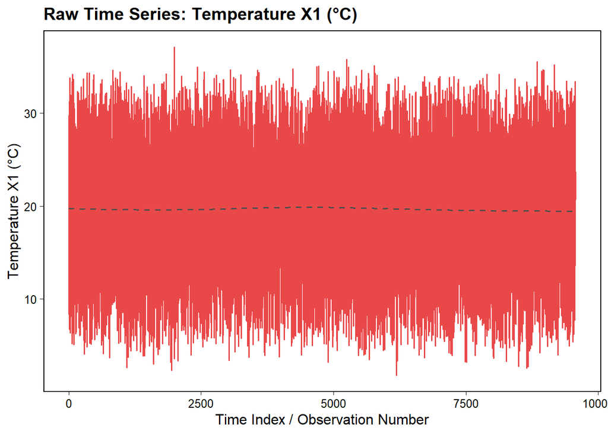

```
##
##
## Generating raw plot for: Net hourly electrical energy output (MW) X2
```

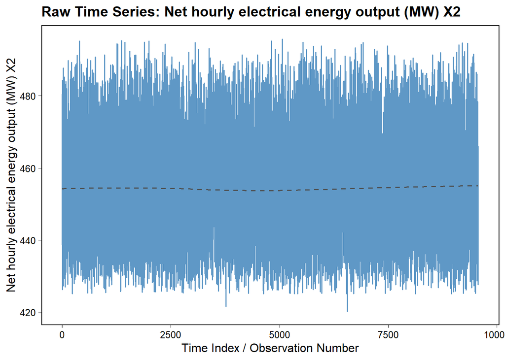

```
##
##
## Generating raw plot for: Ambient Pressure (millibar) X3
```

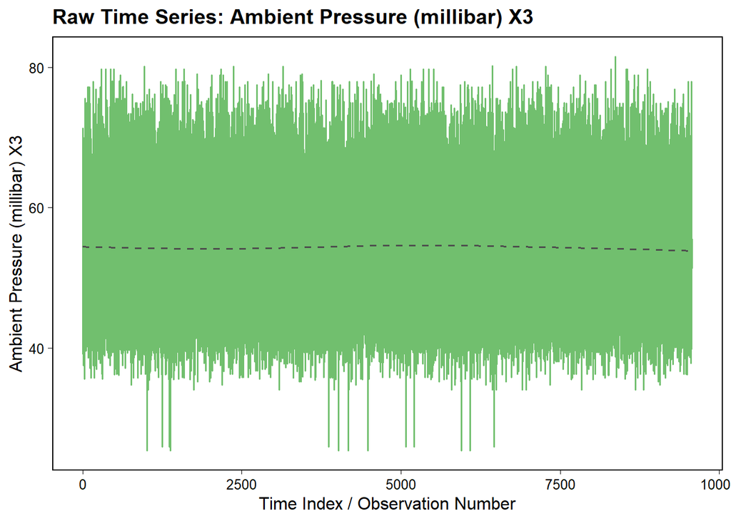

```
##
##
## Generating raw plot for: Relative Humidity (%) X4
```

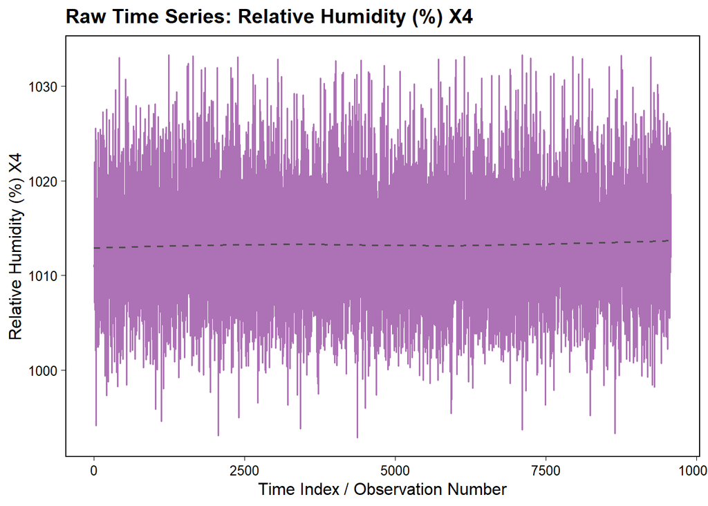

```
##
##
## Generating raw plot for: Exhaust Vacuum (cm Hg) X5
```

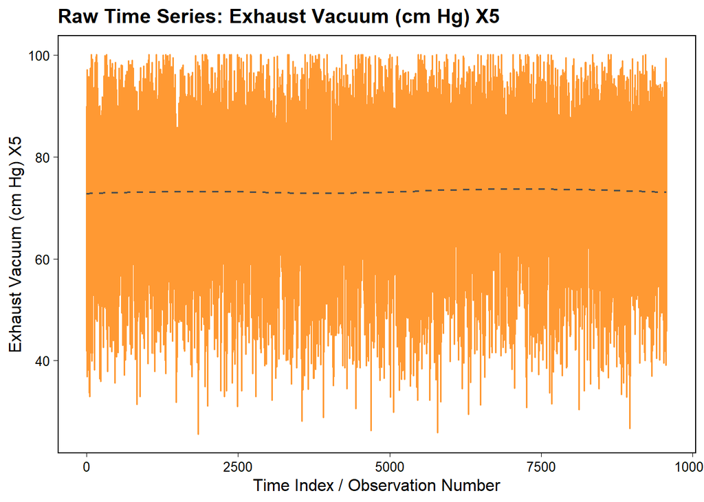

```r
raw_plots_list <- list() # To store individual plots
color_index_raw <- 1 # Initialize color index

for (var_name in names(var_list)) {
  if (var_name %in% names(data_df)) {
    label <- var_list[[var_name]]
    cat(paste0("Generating raw plot for: ", label, "\n"))

    current_color_raw <- plot_colors[color_index_raw]

    p_raw <- ggplot(data_df, aes(x = time_index, y = .data[[var_name]])) +
      geom_line(color = current_color_raw, linewidth = 0.6, alpha = 0.8) + # Main data line
      geom_smooth(method = "loess", se = FALSE, color = "grey30", linetype = "dashed", linewidth = 0.7) + # Smoothed trend line
      labs(
        title = paste0("Raw Time Series: ", label),
        x = "Time Index / Observation Number",
        y = label
      ) +
      theme_linedraw(base_size = 12) + # Using a different theme
      theme(
            plot.title = element_text(face = "bold"),
            plot.subtitle = element_text(size = 9),
            panel.grid.major = element_blank(), # Remove major grid lines
            panel.grid.minor = element_blank()  # Remove minor grid lines
      )

    print(p_raw)
    raw_plots_list[[var_name]] <- p_raw
    cat("\n\n")

    color_index_raw <- color_index_raw + 1
    if (color_index_raw > length(plot_colors)) color_index_raw <- 1 # Recycle colors if more vars than palette colors

  } else {
    cat(paste0("Warning: Variable '", var_name, "' not found in data_df. Skipping raw plot.\n"))
  }
}
```

```r
# Step 5: Define a helper function to aggregate data by averaging over chunks
aggregate_by_index <- function(df, value_col_name, new_aggregated_value_col_name, new_index_col_name, chunk_size) {
  if (!value_col_name %in% names(df)) {
    stop(paste("Column", value_col_name, "not found in the data frame."))
  }
  num_chunks <- floor(nrow(df) / chunk_size)
  if (num_chunks == 0) {
    warning(paste0("Not enough data for even one chunk of size ", chunk_size, " for variable '", value_col_name, "'. Returning empty aggregated data frame."))
    empty_agg_df <- data.frame(matrix(ncol = 2, nrow = 0))
    names(empty_agg_df) <- c(new_index_col_name, new_aggregated_value_col_name)
    return(empty_agg_df)
  }
  df_trimmed <- df[1:(num_chunks * chunk_size), ]
  df_trimmed[[new_index_col_name]] <- rep(1:num_chunks, each = chunk_size)
  if (!is.numeric(df_trimmed[[value_col_name]])) {
      stop(paste("Column", value_col_name, "must be numeric for aggregation."))
  }
  agg_df <- aggregate(df_trimmed[[value_col_name]], by = list(df_trimmed[[new_index_col_name]]), FUN = mean, na.rm = TRUE)
  names(agg_df) <- c(new_index_col_name, new_aggregated_value_col_name)
  return(agg_df)
}

# Step 6: Define a function to generate plots for each variable (aggregated)
generate_aggregated_plot <- function(var_name, label, color_arg) {
  cat(paste0("### Aggregated Time Series Plot (No Grid): ", label, "\n\n"))
  new_val_col <- paste0(var_name, "_agg")
  agg_df <- aggregate_by_index(
    df = data_df,
    value_col_name = var_name,
    new_aggregated_value_col_name = new_val_col,
    new_index_col_name = "index_agg",
    chunk_size = chunk_size_val
  )

  if (nrow(agg_df) == 0) {
      cat(paste0("Skipping aggregated plot for '", label, "' as no data was aggregated.\n\n"))
      return(invisible(NULL)) # Return NULL invisibly if no plot
  }

  p <- ggplot(agg_df, aes(x = index_agg, y = !!sym(new_val_col))) +
    geom_line(color = color_arg, linewidth = 1.2) +
    geom_point(color = color_arg, size = 2, alpha = 0.6) + # Optionally add points
    labs(
      title = paste0("Aggregated Time Series: ", label),
      subtitle = paste0("Data aggregated using a ", chunk_size_val, "-point moving average"),
      x = "Aggregated Index (Chunks)",
      y = paste("Average", label)
    ) +
    theme_linedraw(base_size = 12) +
    theme(
        plot.title = element_text(face = "bold"),
        plot.subtitle = element_text(size = 9),
        panel.grid.major = element_blank(), # Remove major grid lines
        panel.grid.minor = element_blank()  # Remove minor grid lines
    )

  print(p)
  cat("\n\n")
  return(invisible(p)) # Return the plot invisibly
}

# Step 7: Loop through each variable to generate its aggregated plot
cat(paste0("Generating aggregated plots with chunk size: ", chunk_size_val, "\n\n"))
```

```
## Generating aggregated plots with chunk size: 100
```

```
## ### Aggregated Time Series Plot (No Grid): Temperature X1 (°C)
```

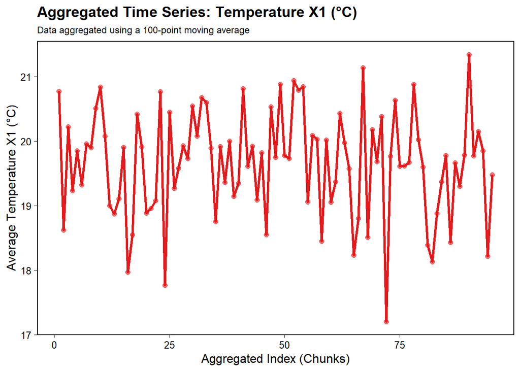

```
##
##
## ### Aggregated Time Series Plot (No Grid): Net hourly electrical energy output (MW) X2
```

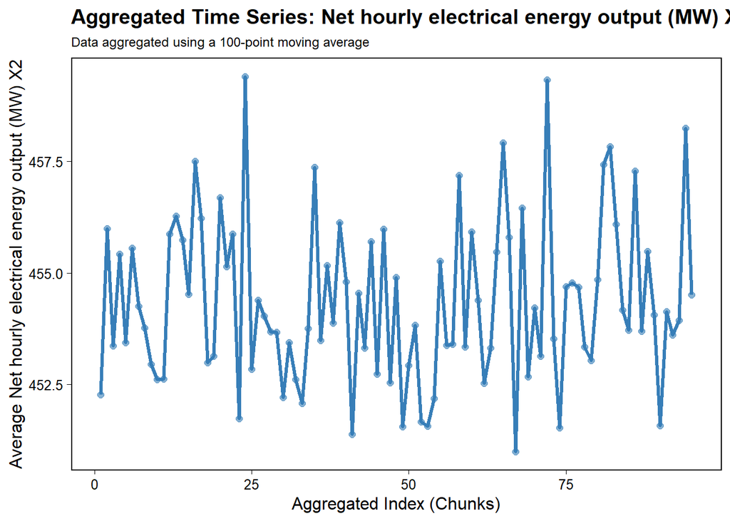

```
##
##
## ### Aggregated Time Series Plot (No Grid): Ambient Pressure (millibar) X3
```

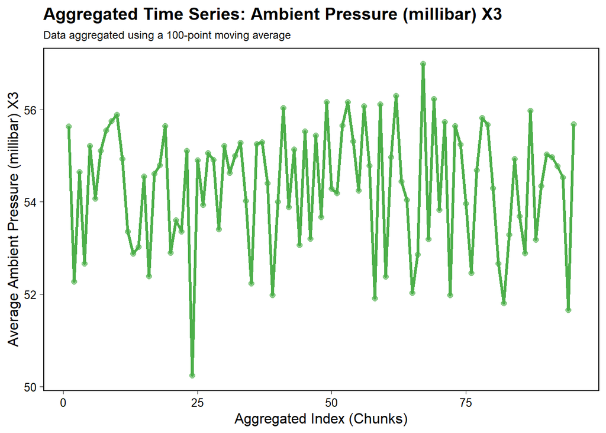

```
##
##
## ### Aggregated Time Series Plot (No Grid): Relative Humidity (%) X4
```

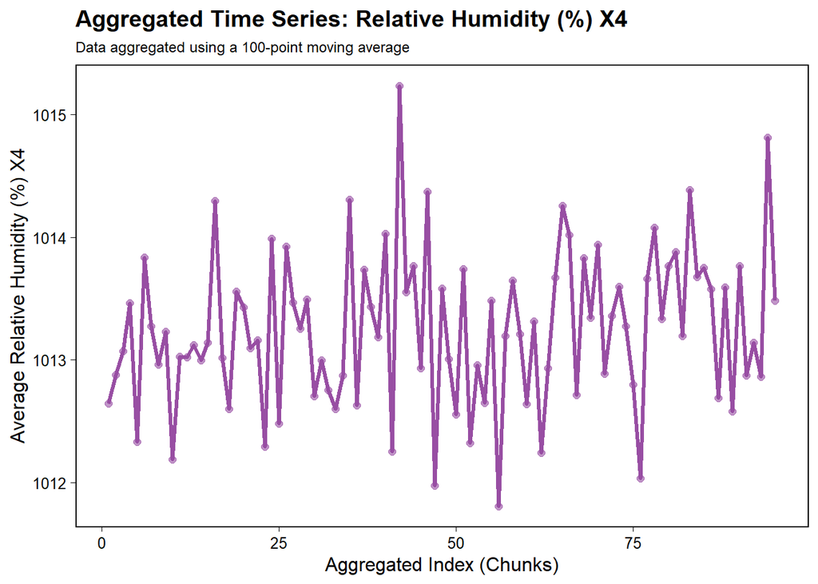

```
##
##
## ### Aggregated Time Series Plot (No Grid): Exhaust Vacuum (cm Hg) X5
```

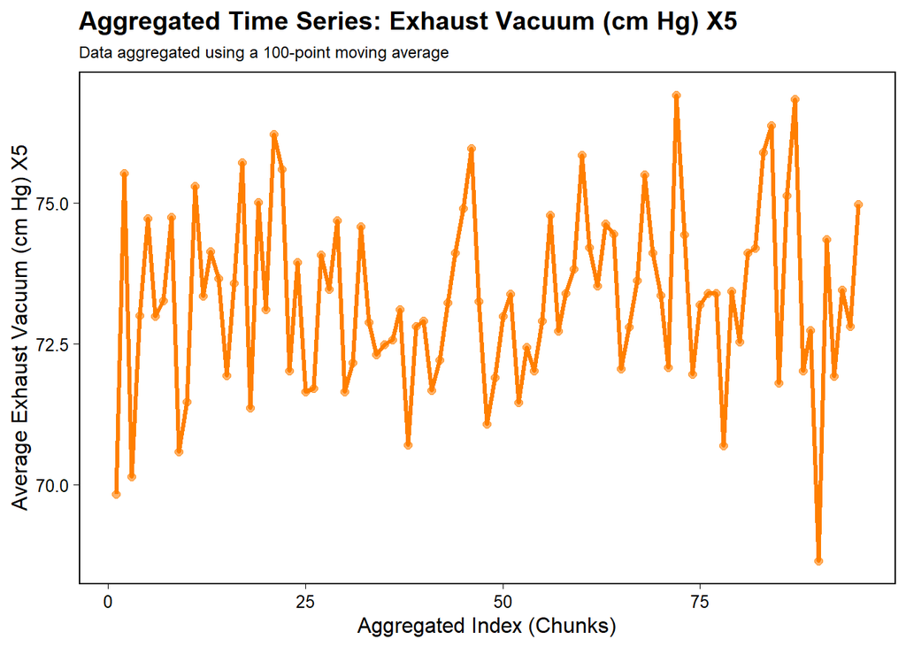

```r
aggregated_plots_list <- list() # To store aggregated plots for potential combination
color_index_agg <- 1

for (v_name in names(var_list)) {
  if (v_name %in% names(data_df)) {
    current_color_agg <- plot_colors[color_index_agg]
    plot_obj <- generate_aggregated_plot(v_name, var_list[[v_name]], current_color_agg)
    if (!is.null(plot_obj)) {
        aggregated_plots_list[[v_name]] <- plot_obj
    }
    color_index_agg <- color_index_agg + 1
    if (color_index_agg > length(plot_colors)) color_index_agg <- 1 # Recycle colors
  } else {
    cat(paste0("Warning: Variable '", v_name, "' not found in data_df. Skipping aggregated plot.\n"))
  }
}
```

```r
cat("Processing complete. All plots generated.\n")
```

```
## Processing complete. All plots generated.
```

1.4 Distribution for Each Signal This chunk defines a function plot_histogram_with_density and then uses it to plot histograms overlaid with density curves for each variable, showing their distributions.

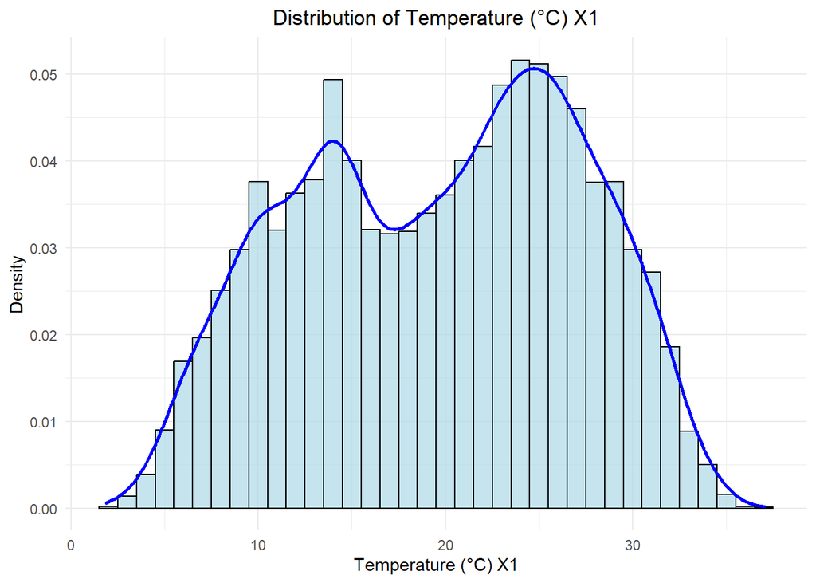

```r
# --- 1.4 Distribution for Each Signal ---

# Histograms and density plots to understand the distribution of each variable.

# Define a function to plot a histogram with an overlaid density curve
plot_histogram_with_density <- function(df, variable, var_name, xlab_label = var_name, color_fill = "lightblue", binwidth_val = NULL) {
  ggplot(df, aes(x = !!sym(variable))) + # Use !!sym() for unquoting the variable name
    geom_histogram(aes(y = after_stat(density)), binwidth = binwidth_val, fill = color_fill, color = "black", alpha = 0.7) + # Histogram layer
    geom_density(color = "blue", linewidth = 1) + # Density curve layer
    labs(title = paste("Distribution of", var_name), x = xlab_label, y = "Density") + # Labels and title
    theme(plot.title = element_text(hjust = 0.5)) # Center plot title
}

# Plot distributions for each variable
plot_histogram_with_density(data_df, "x1", "Temperature (°C) X1", binwidth_val = 1)
```

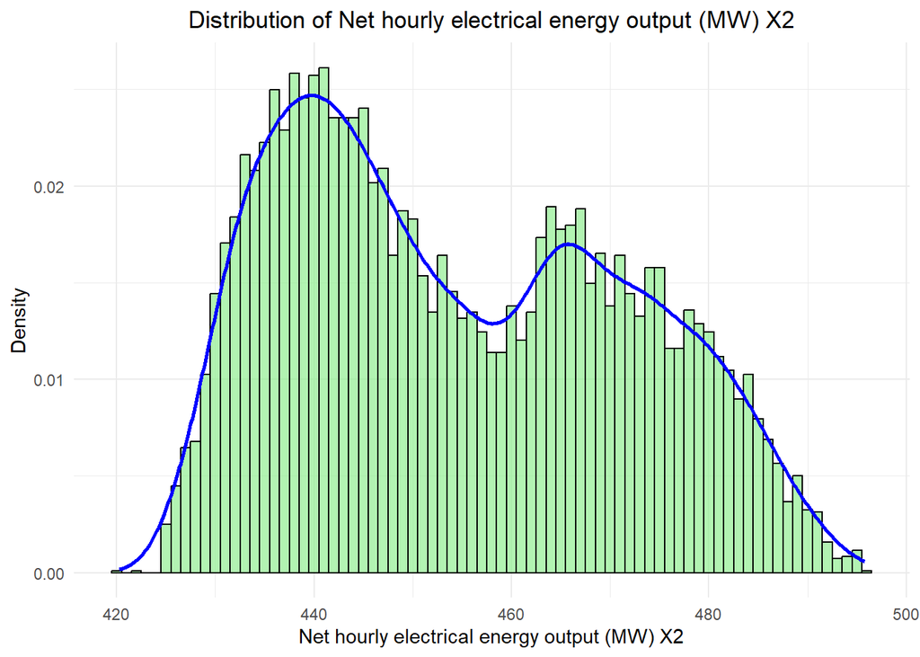

```r
plot_histogram_with_density(data_df, "x2", "Net hourly electrical energy output (MW) X2", color_fill = "lightgreen", binwidth_val = 1)
```

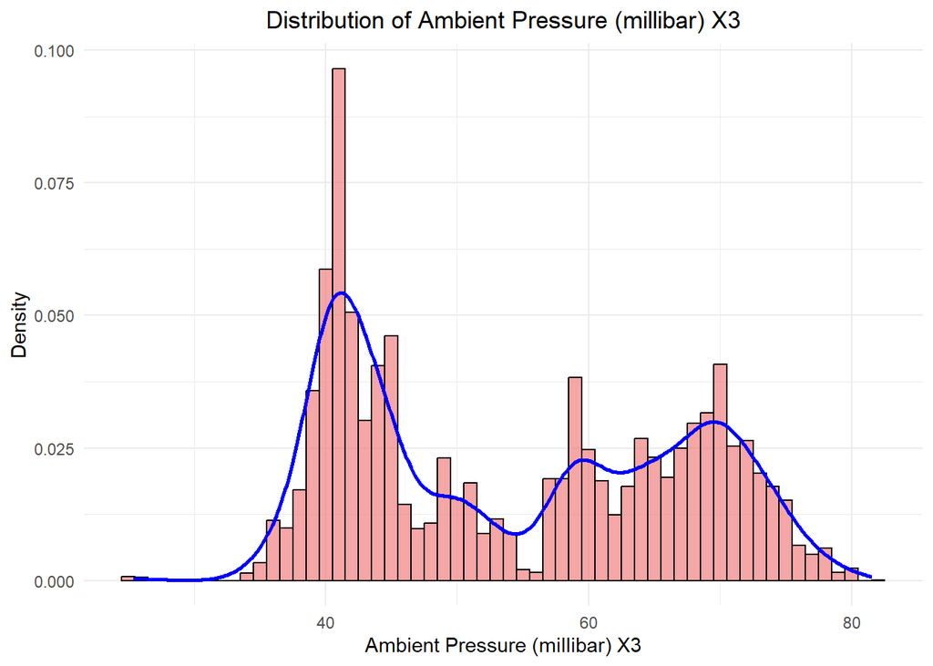

```r
plot_histogram_with_density(data_df, "x3", "Ambient Pressure (millibar) X3", color_fill = "lightcoral", binwidth_val = 1)
```

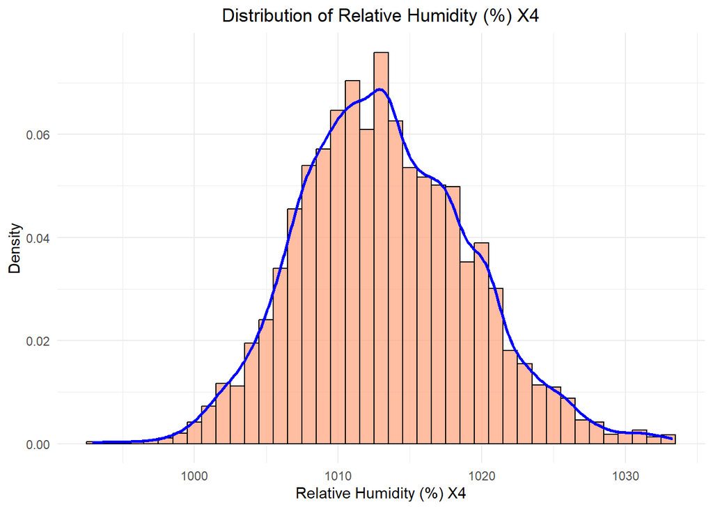

```r
plot_histogram_with_density(data_df, "x4", "Relative Humidity (%) X4", color_fill = "lightsalmon", binwidth_val = 1)
```

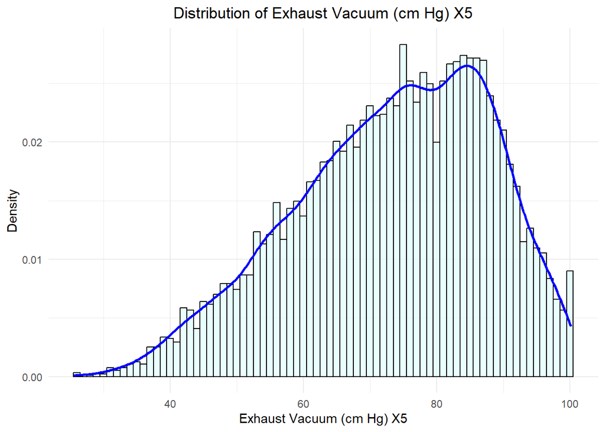

```r
plot_histogram_with_density(data_df, "x5", "Exhaust Vacuum (cm Hg) X5", color_fill = "lightcyan", binwidth_val = 1)
```

1.5 Correlation and Scatter Plots This section first calculates and prints the correlation matrix for all variables in data_df. Then, it visualizes this matrix using corrplot. After that, it generates individual scatter plots to show the relationship between each predictor and the output variable (x2).

```r
# --- 1.5 Correlation and Scatter Plots ---

# Examining linear relationships between variables.

# Calculate the correlation matrix
corr_matrix <- cor(data_df)
cat("Correlation Matrix:\n")
```

```
## Correlation Matrix:
```

```r
print(corr_matrix) # Print the correlation matrix
```

```
##                      x1           x3          x4          x5           x2
## x1          1.000000000  0.844106732 -0.50754934 -0.54253465 -0.948128470
## x3          0.844106732  1.000000000 -0.41350216 -0.31218728 -0.869780310
## x4         -0.507549339 -0.413502158  1.00000000  0.09957432  0.518429027
## x5         -0.542534652 -0.312187282  0.09957432  1.00000000  0.389794100
## x2         -0.948128470 -0.869780310  0.51842903  0.38979410  1.000000000
## time_index -0.006899309 -0.001902467  0.02204699  0.01036870  0.008107132
##              time_index
## x1         -0.006899309
## x3         -0.001902467
## x4          0.022046990
## x5          0.010368696
## x2          0.008107132
## time_index  1.000000000
```

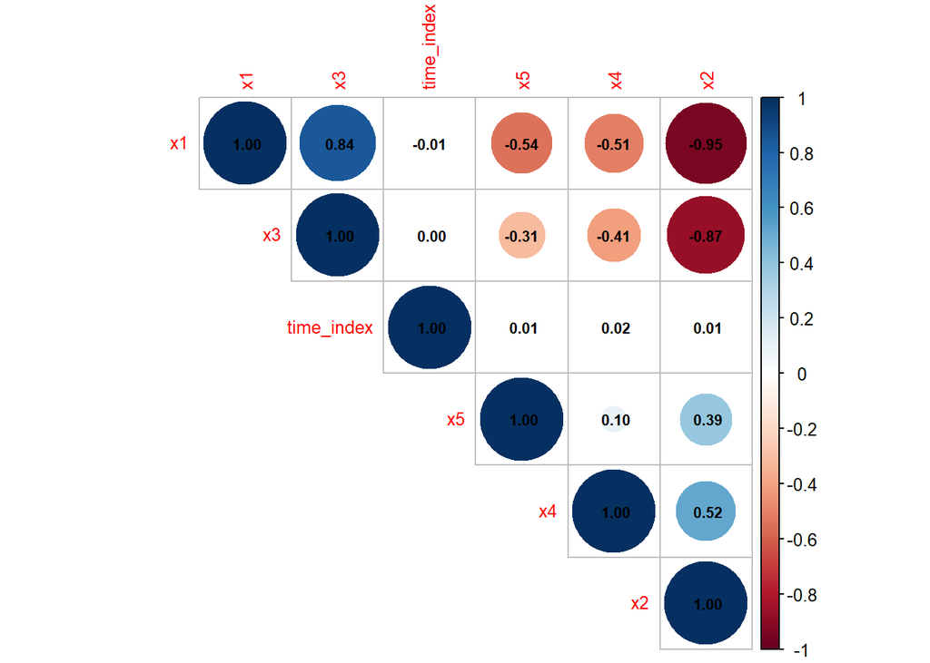

```r
# Plot the correlation matrix
corrplot(
  corr_matrix,
  method = "circle",    # Use circles to represent correlation strength
  tl.cex = 0.8,         # Text label size for variable names
  type = "upper",       # Display the upper triangle of the matrix
  order = "hclust",     # Order variables using hierarchical clustering
  addCoef.col = "black", # Add correlation coefficients to the plot in black
  number.cex = 0.7      # Size of the correlation coefficients
)
```

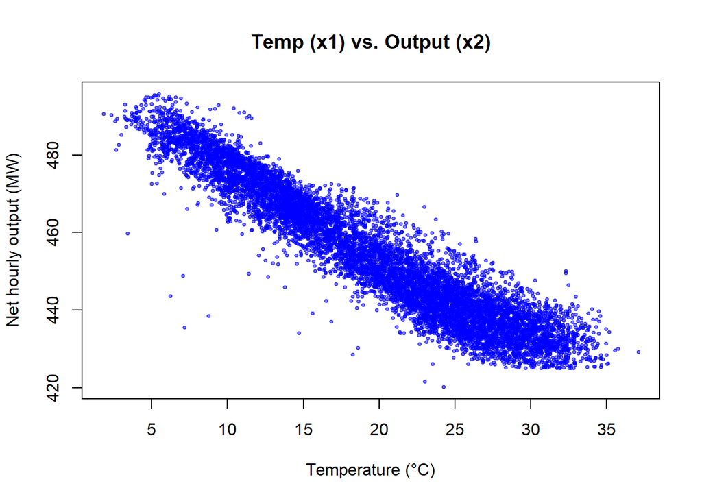

```r
# --- Arrange scatter plots ---
# Scatter plots displayed individually

# Plot 1: Temperature (x1) vs. Net hourly electrical energy output (x2)
plot(data_df$x1, data_df$x2,
     main = "Temp (x1) vs. Output (x2)",        # Plot title
     xlab = "Temperature (°C)",                 # X-axis label
     ylab = "Net hourly output (MW)",           # Y-axis label
     col = alpha("blue", 0.5),                 # Point color with transparency
     pch = 19,                                 # Plotting character (solid circle)
     cex = 0.5                                 # Point size
)
```

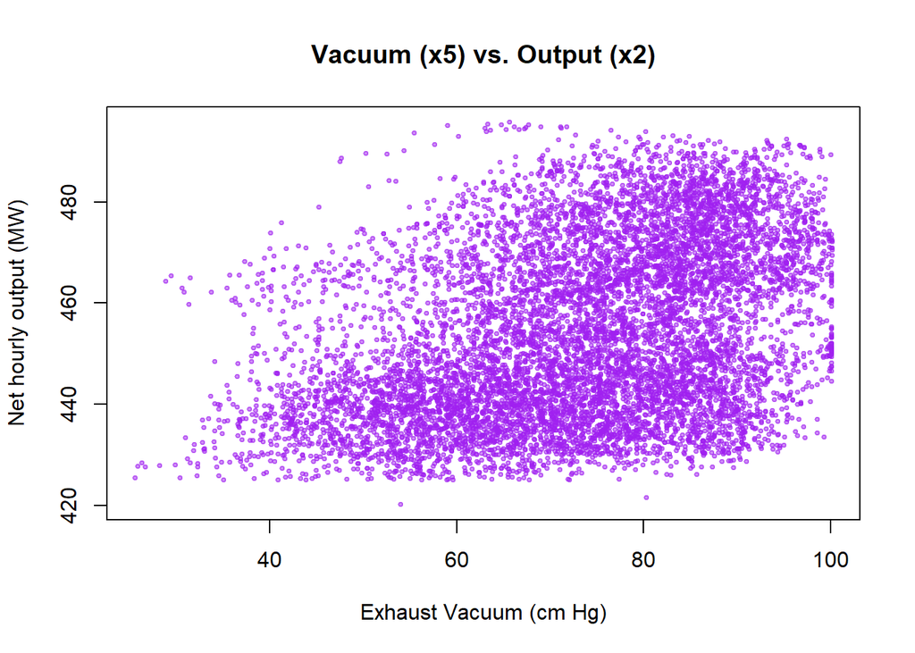

```r
# Plot 2: Exhaust Vacuum (x5) vs. Net hourly electrical energy output (x2)
plot(data_df$x5, data_df$x2,
     main = "Vacuum (x5) vs. Output (x2)",
     xlab = "Exhaust Vacuum (cm Hg)",
     ylab = "Net hourly output (MW)",
     col = alpha("purple", 0.5),
     pch = 19,
     cex = 0.5
)
```

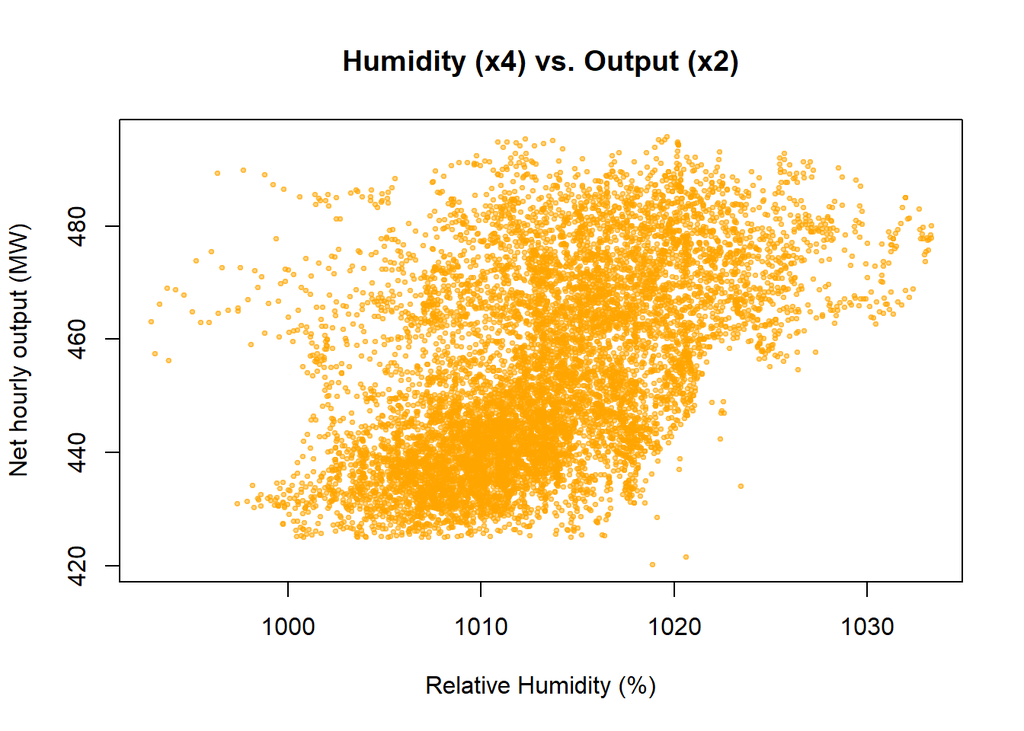

```r
# Plot 3: Relative Humidity (x4) vs. Net hourly electrical energy output (x2)
plot(data_df$x4, data_df$x2,
     main = "Humidity (x4) vs. Output (x2)",
     xlab = "Relative Humidity (%)",
     ylab = "Net hourly output (MW)",
     col = alpha("orange", 0.5),
     pch = 19,
     cex = 0.5
)
```

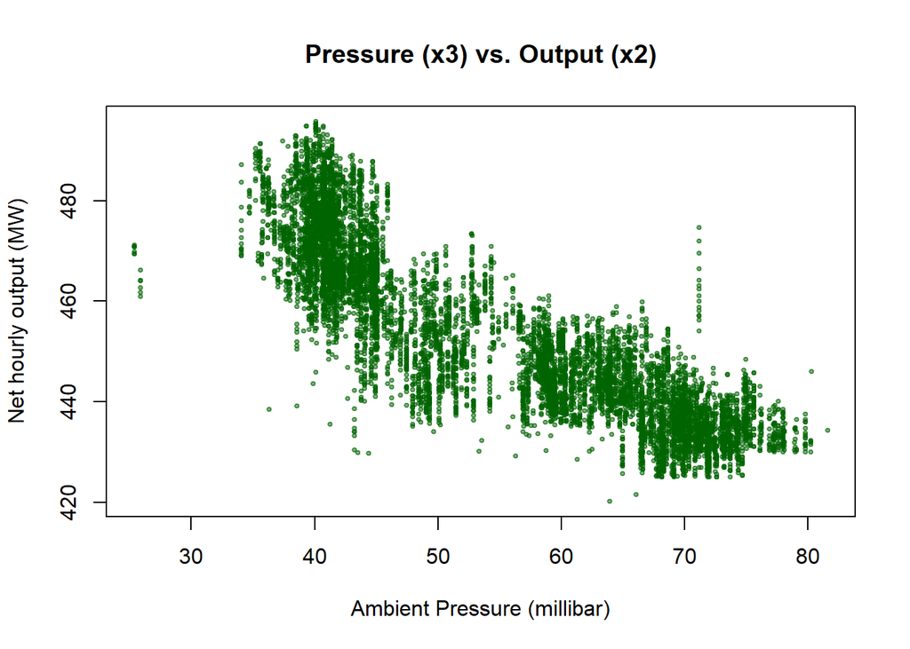

```r
# Plot 4: Ambient Pressure (x3) vs. Net hourly electrical energy output (x2)
plot(data_df$x3, data_df$x2,
     main = "Pressure (x3) vs. Output (x2)",
     xlab = "Ambient Pressure (millibar)",
     ylab = "Net hourly output (MW)",
     col = alpha("darkgreen", 0.5),
     pch = 19,
     cex = 0.5
)
```

Task 2: Regression – Modelling the Relationship This task aims to find a suitable mathematical model from five candidates to explain the relationship between the input variables and the net hourly electrical energy output (y = x2).

First, the response variable y_response is defined, and then a list model_definitions is created. This list stores data frames of the predictor variables (and their transformations like squares or cubes) for each of the five candidate models.

```r
# --- Task 2: Regression – Modelling the Relationship ---

# The candidate models are:
#   Model 1: y = θ₁·x₄ + θ₂·x₃² + θ_bias
#   Model 2: y = θ₁·x₄ + θ₂·x₃² + θ₃·x₅ + θ_bias
#   Model 3: y = θ₁·x₃ + θ₂·x₄ + θ₃·x₅³ + θ_bias
#   Model 4: y = θ₁·x₄ + θ₂·x₃² + θ₃·x₅³ + θ_bias
#   Model 5: y = θ₁·x₄ + θ₂·x₁² + θ₃·x₃² + θ_bias

# Define y (response vector)
y_response <- data_df$x2 # The net hourly electrical energy output

# Define model_data (list of predictor data frames for each model)
# Each element in the list corresponds to a model and contains
# the transformed predictor variables for that model.
model_definitions <- list(
  model1 = data.frame(x4 = data_df$x4, x3_sq = data_df$x3^2), # Predictors for Model 1
  model2 = data.frame(x4 = data_df$x4, x3_sq = data_df$x3^2, x5 = data_df$x5), # Predictors for Model 2
  model3 = data.frame(x3 = data_df$x3, x4 = data_df$x4, x5_cubed = data_df$x5^3), # Predictors for Model 3
  model4 = data.frame(x4 = data_df$x4, x3_sq = data_df$x3^2, x5_cubed = data_df$x5^3), # Predictors for Model 4
  model5 = data.frame(x4 = data_df$x4, x1_sq = data_df$x1^2, x3_sq = data_df$x3^2) # Predictors for Model 5
)
```

2.1 Estimate Model Parameters ( theta) This chunk defines a function estimate_theta_ols_scaled to estimate model parameters using Ordinary Least Squares (OLS) on scaled predictors. The predictors are scaled (standardized) before fitting. The function handles intercept-only models and cases with insufficient data. It then iterates through each defined model, scales its predictors, estimates the parameters ( hattheta), and stores both the estimated parameters and the processed design matrix (X with intercept and scaled predictors).

```r
# --- 2.1 Estimate Model Parameters (θ) ---

# We use Ordinary Least Squares (OLS) on scaled predictors.
# θ_hat = (XᵀX)⁻¹ Xᵀy. Lambda is set to 0 for OLS.

lambda_ols_param <- 0 # Setting lambda to 0 for Ordinary Least Squares (no regularization)

# Function to estimate theta using OLS with scaled predictors
estimate_theta_ols_scaled <- function(X_scaled_no_intercept, y_response_vec, lambda_val) {
  # Handle intercept-only model (if X_scaled_no_intercept has columns but no rows, or no columns)
  if (ncol(X_scaled_no_intercept) == 0 && nrow(X_scaled_no_intercept) > 0) {
    X_final_mat <- matrix(1, nrow = nrow(X_scaled_no_intercept), ncol = 1) # Design matrix for intercept-only
    colnames(X_final_mat) <- c("(Intercept)")
  } else if (nrow(X_scaled_no_intercept) > 0) { # Model with predictors
    X_final_mat <- cbind("(Intercept)" = rep(1, nrow(X_scaled_no_intercept)), X_scaled_no_intercept) # Add intercept column
  } else { # No data
     warning("Input X_scaled_no_intercept has 0 rows.")
     return(NA) # Return NA if no data
  }

  # Check if there are enough data points for the number of parameters
  if (nrow(X_final_mat) < ncol(X_final_mat)) {
    warning(paste0("Skipping OLS - not enough rows (", nrow(X_final_mat),
                  ") for predictors (", ncol(X_final_mat), ")."))
    return(NA) # Return NA if not enough data
  }

  # Calculate theta_hat using the OLS formula with potential regularization (lambda_val)
  theta_hat <- tryCatch({
    XtX <- t(X_final_mat) %*% X_final_mat # X transpose X
    penalty_matrix <- lambda_val * diag(ncol(X_final_mat)) # Penalty matrix for Ridge regression (0 if lambda_val=0)
    if (ncol(X_final_mat) > 0) penalty_matrix[1,1] <- 0 # Intercept is typically not penalized
    XtX_reg <- XtX + penalty_matrix # Regularized XtX (or just XtX if lambda_val is 0)

    # Use Moore-Penrose generalized inverse (ginv) for numerical stability
    estimated_coeffs <- MASS::ginv(XtX_reg) %*% t(X_final_mat) %*% y_response_vec
    rownames(estimated_coeffs) <- colnames(X_final_mat) # Assign names to coefficients
    return(estimated_coeffs)
  }, error = function(e) {
    message(paste0("Error calculating theta_hat with OLS: ", e$message))
    return(NA) # Return NA on error
  })
  return(theta_hat)
}

# Initialize lists to store results for all models
theta_list_all_models <- list() # To store estimated parameters (theta_hat)
X_final_processed_list_all_models <- list() # To store the design matrix (X with intercept and scaled predictors)

# Loop through each model definition
for (model_label in names(model_definitions)) {
  cat("\nProcessing model:", model_label, "\n")
  X_raw_current_df <- model_definitions[[model_label]] # Get raw predictors for the current model

  # Skip if model data is null or empty
  if (is.null(X_raw_current_df) || nrow(X_raw_current_df) == 0) {
    theta_list_all_models[[model_label]] <- NA
    X_final_processed_list_all_models[[model_label]] <- NA
    next
  }

  X_raw_current_mat <- as.matrix(X_raw_current_df) # Convert to matrix
  X_scaled_current_no_int <- matrix(nrow = nrow(X_raw_current_mat), ncol = 0) # Initialize scaled matrix (no intercept yet)

  # Scale predictors if there are any
  if (ncol(X_raw_current_mat) > 0) {
    original_colnames <- colnames(X_raw_current_mat) # Store original column names
    # Assign default column names if missing
    if (is.null(original_colnames)) {
        original_colnames <- if(ncol(X_raw_current_mat) == 1 && !is.null(names(X_raw_current_df))) names(X_raw_current_df) else paste0("V", 1:ncol(X_raw_current_mat))
    }
    X_scaled_temp_mat <- scale(X_raw_current_mat) # Scale the predictors (center and scale)
    X_scaled_temp_mat[is.na(X_scaled_temp_mat)] <- 0 # Replace any NA/NaN from scaling (e.g., constant column) with 0
    X_scaled_current_no_int <- X_scaled_temp_mat
    colnames(X_scaled_current_no_int) <- original_colnames # Restore column names
  }

  # Estimate theta_hat for the current model using scaled predictors
  current_theta_hat_val <- estimate_theta_ols_scaled(X_scaled_current_no_int, y_response, lambda_val = lambda_ols_param)
  theta_list_all_models[[model_label]] <- current_theta_hat_val # Store estimated theta

  # Store the final processed design matrix (with intercept and scaled predictors)
  if (!is.null(current_theta_hat_val) && !all(is.na(current_theta_hat_val))) {
      X_final_processed_list_all_models[[model_label]] <- if (ncol(X_scaled_current_no_int) == 0 && nrow(X_scaled_current_no_int) > 0) {
          # Design matrix for intercept-only model
          matrix(1, nrow = nrow(X_scaled_current_no_int), ncol = 1, dimnames = list(NULL, "(Intercept)"))
      } else if (nrow(X_scaled_current_no_int) > 0) {
          # Design matrix with intercept and scaled predictors
          cbind("(Intercept)" = rep(1, nrow(X_scaled_current_no_int)), X_scaled_current_no_int)
      } else { NA }
  } else {
      X_final_processed_list_all_models[[model_label]] <- NA # Store NA if theta estimation failed
  }
  cat("Theta_hat for", model_label, "(OLS on scaled predictors):\n"); print(current_theta_hat_val)
}
```

```
##
## Processing model: model1
## Theta_hat for model1 (OLS on scaled predictors):
##                   [,1]
## (Intercept) 454.365009
## x4            3.348278
## x3_sq       -13.211452
##
## Processing model: model2
## Theta_hat for model2 (OLS on scaled predictors):
##                   [,1]
## (Intercept) 454.365009
## x4            3.432657
## x3_sq       -12.406622
## x5            2.517326
##
## Processing model: model3
## Theta_hat for model3 (OLS on scaled predictors):
##                   [,1]
## (Intercept) 454.365009
## x3          -12.722943
## x4            3.402683
## x5_cubed      2.315840
##
## Processing model: model4
## Theta_hat for model4 (OLS on scaled predictors):
##                   [,1]
## (Intercept) 454.365009
## x4            3.487220
## x3_sq       -12.402038
## x5_cubed      2.487015
##
## Processing model: model5
## Theta_hat for model5 (OLS on scaled predictors):
##                   [,1]
## (Intercept) 454.365009
## x4            1.349107
## x1_sq       -10.605331
## x3_sq        -5.173124
```

2.2 Compute Residual Sum of Squared Errors (RSS) This chunk defines a function compute_rss_func to calculate the RSS. It then iterates through each model, retrieves the estimated parameters ( hattheta) and the processed design matrix, calculates the predicted values (y_pred=X hattheta), and then computes the RSS. The RSS values for all models are stored and printed.

```r
# --- 2.2 Compute Residual Sum of Squared Errors (RSS) ---
# RSS = Σ(yᵢ - xᵢᵀθ̂)² from i=1 to n

# Function to compute RSS
compute_rss_func <- function(y_true, y_pred) {
  if (length(y_true) != length(y_pred)) stop("Length of y_true and y_pred must be the same.")
  sum((y_true - y_pred)^2, na.rm = TRUE) # Sum of squared differences, remove NA if any
}

# Calculate RSS for each model
rss_list_all_models <- lapply(names(model_definitions), function(model_name) {
  current_theta <- theta_list_all_models[[model_name]]         # Get estimated parameters for the model
  X_processed_mat <- X_final_processed_list_all_models[[model_name]] # Get the processed design matrix

  # Return NA if parameters or design matrix are NA, or if dimensions don't match
  if (any(is.na(current_theta)) || any(is.na(X_processed_mat))) return(NA)
  if (ncol(X_processed_mat) != length(current_theta)) return(NA)

  # Predict y values using Xθ̂
  y_pred_vals <- tryCatch(X_processed_mat %*% current_theta, error = function(e) NULL)
  if (is.null(y_pred_vals)) return(NA) # Return NA if prediction fails

  # Compute RSS
  rss_val <- compute_rss_func(y_response, y_pred_vals)
  return(rss_val)
})
names(rss_list_all_models) <- names(model_definitions) # Assign model names to the RSS list

cat("\n--- Calculated RSS for all models ---\n")
```

```
##
## --- Calculated RSS for all models ---
```

```r
print(data.frame(Model = names(rss_list_all_models), RSS = unlist(rss_list_all_models))) # Print RSS for all models
```

```
##         Model      RSS
## model1 model1 657248.2
## model2 model2 602347.1
## model3 model3 547491.6
## model4 model4 603630.7
## model5 model5 365625.0
```

2.3 Compute Log-Likelihood and Variance This chunk defines a function compute_loglik_var_func to calculate the log-likelihood and the variance ( hatsigma^2) of the errors. The variance is calculated as RSS/(n−1) as per assignment instructions. The log-likelihood is then computed using this variance and the RSS. These calculations are performed for each model, and the results are stored and printed.

```r
# --- 2.3 Compute Log-Likelihood and Variance ---
# Log-likelihood: ln p(D|θ̂) = -n/2 ln(2π) - n/2 ln(σ̂²) - (1/(2σ̂²))RSS
# Variance: σ̂² = RSS / (n-1)

# Function to compute log-likelihood and variance
compute_loglik_var_func <- function(rss_val, n_obs, k_params) {
  # Estimate variance of errors (σ̂²) as RSS / (n-1) based on assignment instruction
  # Note: A common alternative for σ̂² in regression is RSS / (n - k_params)
  sigma_sq_est <- rss_val / (n_obs - 1)

  # If variance is non-positive (e.g., RSS=0 and n=1, or numerical issues), log-likelihood is -Inf
  if(sigma_sq_est <= 0) return(list(log_likelihood = -Inf, variance = sigma_sq_est))

  # Calculate log-likelihood
  log_lik_val <- -(n_obs / 2) * log(2 * pi) - (n_obs / 2) * log(sigma_sq_est) - (1 / (2 * sigma_sq_est)) * rss_val
  list(log_likelihood = log_lik_val, variance = sigma_sq_est)
}

# Calculate log-likelihood and variance for each model
loglik_var_list_all_models <- lapply(names(rss_list_all_models), function(model_name) {
  rss_val <- rss_list_all_models[[model_name]] # Get RSS for the model
  # Get the number of estimated parameters (k) for the model (including intercept)
  k_params_val <- length(theta_list_all_models[[model_name]][!is.na(theta_list_all_models[[model_name]])])

  if (is.na(rss_val)) return(list(log_likelihood = NA, variance = NA)) # Return NA if RSS is NA

  results <- compute_loglik_var_func(rss_val, length(y_response), k_params_val)
  return(results)
})
names(loglik_var_list_all_models) <- names(model_definitions) # Assign model names

cat("\n--- Log-Likelihood and Variance for all models ---\n")
```

```
##
## --- Log-Likelihood and Variance for all models ---
```

```r
print(data.frame(Model = names(loglik_var_list_all_models),
                 LogLikelihood = sapply(loglik_var_list_all_models, `[[`, "log_likelihood"),
                 Variance = sapply(loglik_var_list_all_models, `[[`, "variance"))) # Print results
```

```
##         Model LogLikelihood Variance
## model1 model1     -33810.99 68.69951
## model2 model2     -33393.69 62.96091
## model3 model3     -32936.88 57.22710
## model4 model4     -33403.88 63.09509
## model5 model5     -31005.40 38.21731
```

2.4 Compute AIC and BIC This chunk defines functions to calculate the Akaike Information Criterion (AIC) and Bayesian Information Criterion (BIC). AIC and BIC are then computed for each model using their log-likelihood values and the number of estimated parameters (k). The results are stored and printed.

```r
# --- 2.4 Compute AIC and BIC ---
# AIC = 2k - 2 ln p(D|θ̂)
# BIC = k ln(n) - 2 ln p(D|θ̂)
# where k is the number of estimated parameters.

# Function to compute AIC
compute_aic_val_func <- function(log_likelihood, k_params) 2 * k_params - 2 * log_likelihood

# Function to compute BIC
compute_bic_val_func <- function(log_likelihood, k_params, n_obs) k_params * log(n_obs) - 2 * log_likelihood

# Calculate AIC and BIC for each model
aic_bic_list_all_models <- lapply(names(model_definitions), function(model_name) {
  log_lik_val <- loglik_var_list_all_models[[model_name]]$log_likelihood # Get log-likelihood
  theta_vec <- theta_list_all_models[[model_name]] # Get estimated parameters
  # k_params_val is the number of non-NA estimated parameters (includes intercept)
  k_params_val <- length(theta_vec[!is.na(theta_vec)])

  if (is.na(log_lik_val)) return(list(AIC = NA, BIC = NA)) # Return NA if log-likelihood is NA

  aic_val <- compute_aic_val_func(log_lik_val, k_params_val) # Compute AIC
  bic_val <- compute_bic_val_func(log_lik_val, k_params_val, length(y_response)) # Compute BIC
  return(list(AIC = aic_val, BIC = bic_val))
})
names(aic_bic_list_all_models) <- names(model_definitions) # Assign model names

cat("\n--- AIC and BIC for all models ---\n")
```

```
##
## --- AIC and BIC for all models ---
```

```r
print(data.frame(Model = names(aic_bic_list_all_models),
                 AIC = sapply(aic_bic_list_all_models, `[[`, "AIC"),
                 BIC = sapply(aic_bic_list_all_models, `[[`, "BIC"))) # Print AIC and BIC
```

```
##         Model      AIC      BIC
## model1 model1 67627.98 67649.48
## model2 model2 66795.38 66824.05
## model3 model3 65881.77 65910.43
## model4 model4 66815.75 66844.42
## model5 model5 62018.79 62047.46
```

2.5 Checking the Distribution of Model Prediction Errors (Residuals) This chunk defines a function plot_qq_residuals_func to create Q-Q (Quantile-Quantile) plots for model residuals. These plots help assess if the residuals are normally distributed. The chunk then calculates predictions for each model, computes the residuals (y_true−y_pred), and generates a Q-Q plot for each model’s residuals.

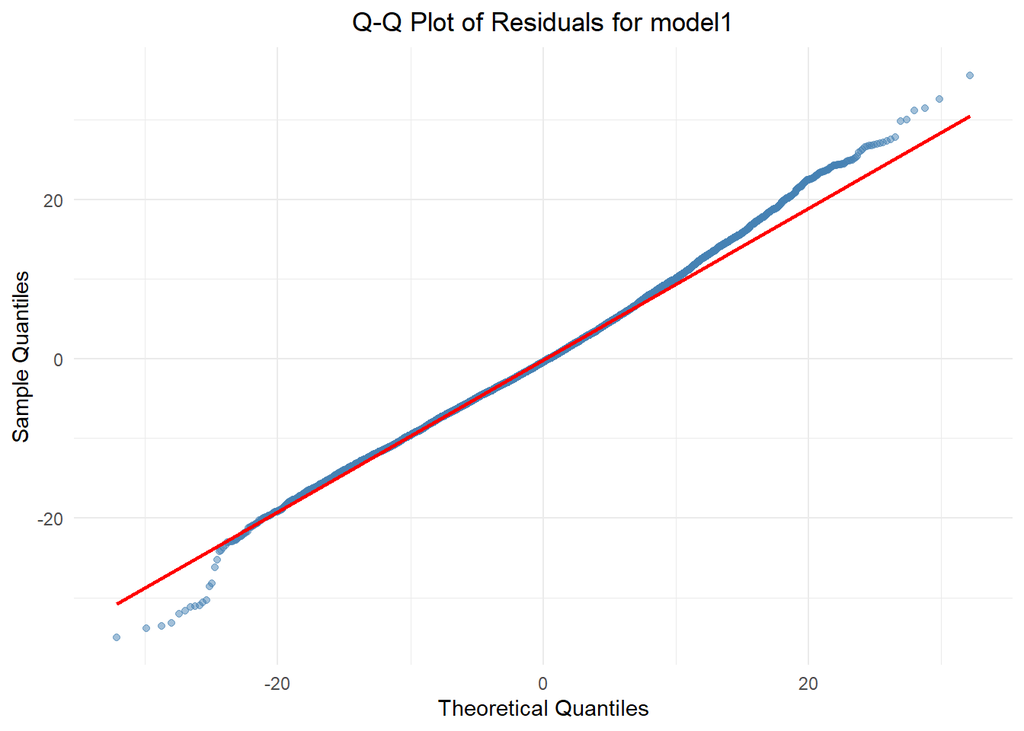

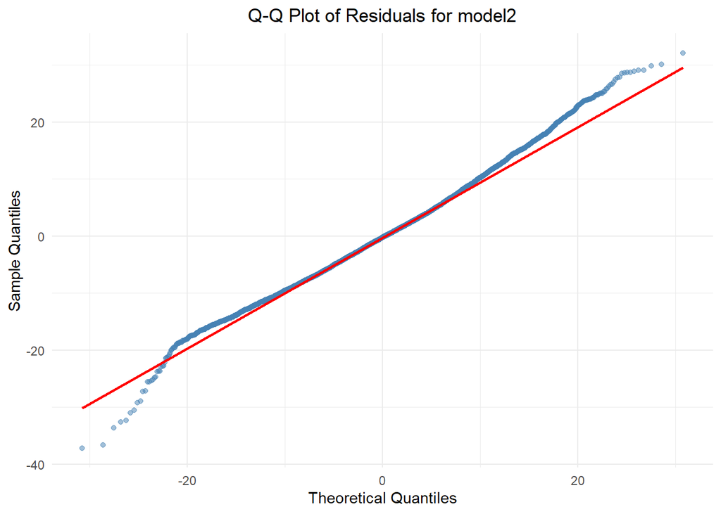

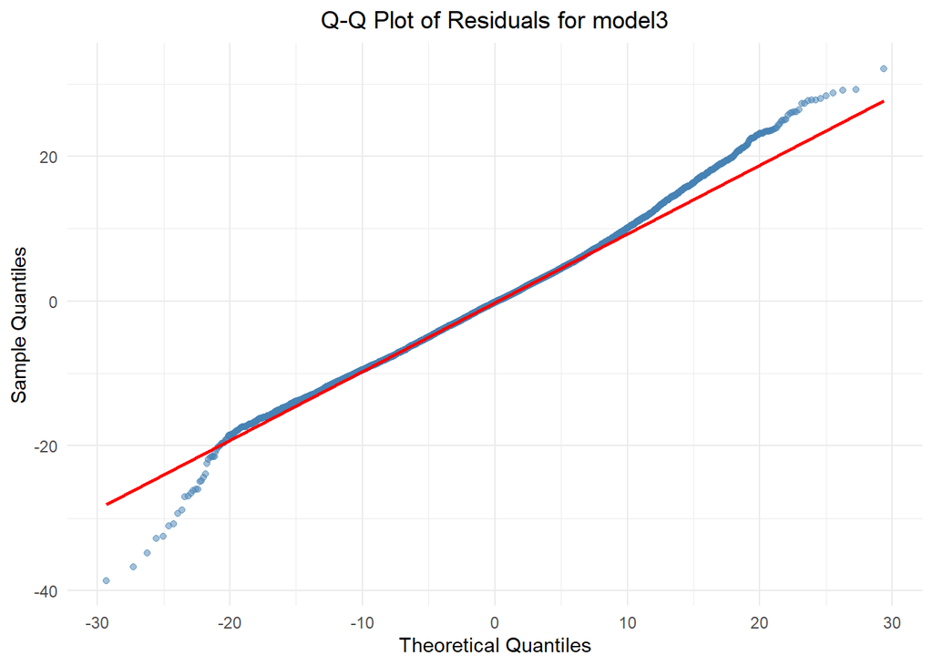

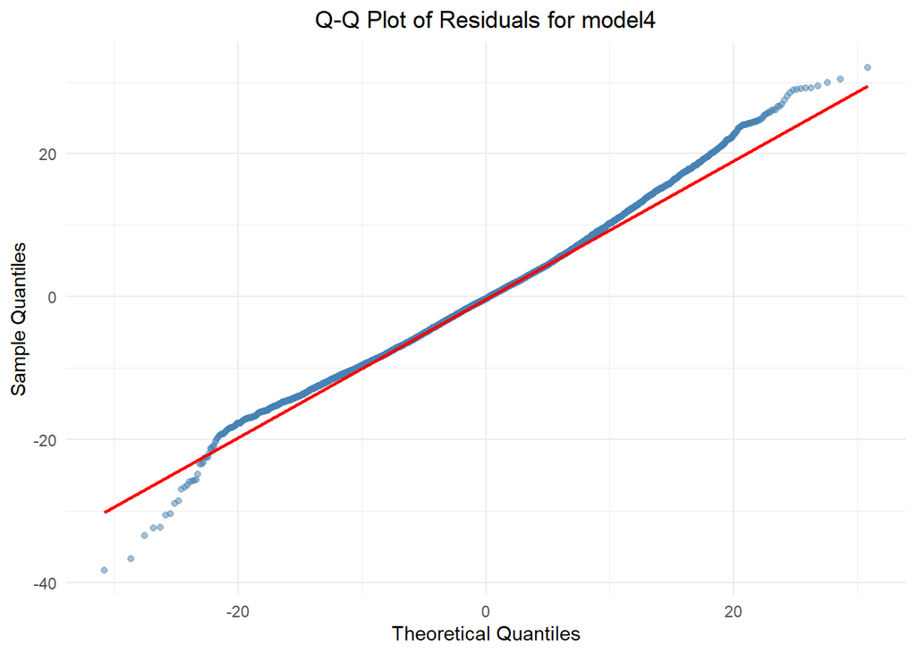

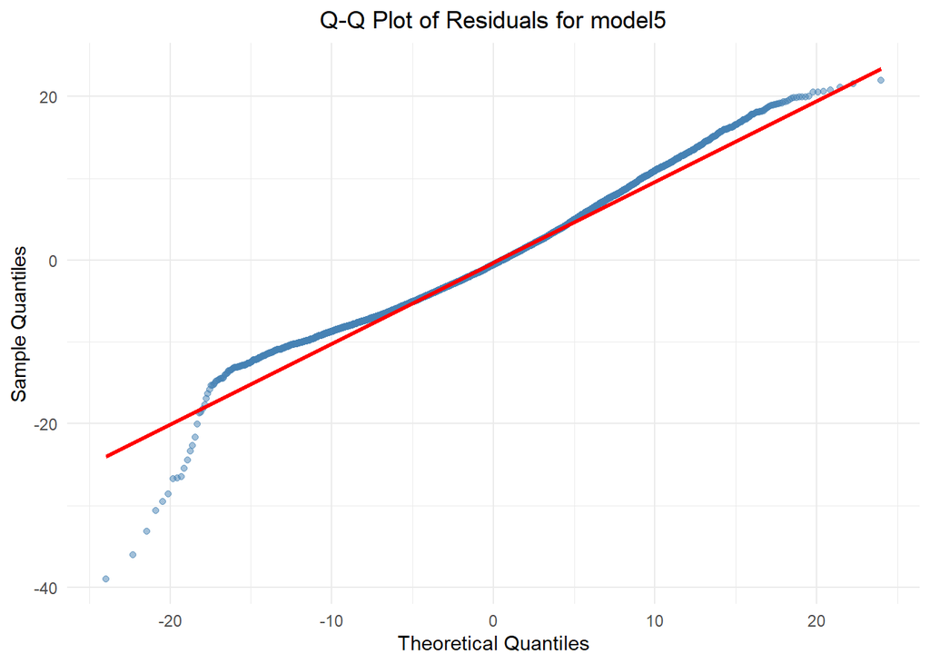

```r
# --- 2.5 Checking the Distribution of Model Prediction Errors (Residuals) ---

# We use Q-Q plots to check if residuals are normally distributed.

# Function to plot Q-Q plot of residuals
plot_qq_residuals_func <- function(y_true, y_pred, model_name_str) {
  residuals_vec <- y_true - y_pred # Calculate residuals
  p <- ggplot(data.frame(residuals = residuals_vec), aes(sample = residuals)) +
    stat_qq_point(color = "steelblue", size = 1.5, alpha = 0.5) + # Q-Q plot points
    stat_qq_line(color = "red", linewidth = 1) +                    # Reference line for normal distribution
    labs(title = paste("Q-Q Plot of Residuals for", model_name_str),
         x = "Theoretical Quantiles", y = "Sample Quantiles") +
    theme(plot.title = element_text(hjust = 0.5)) # Center plot title
  print(p) # Print the plot
}

# Get predictions for all models
predictions_list_all_models <- lapply(names(model_definitions), function(model_name) {
  theta_vec <- theta_list_all_models[[model_name]]             # Get parameters
  X_processed_mat <- X_final_processed_list_all_models[[model_name]] # Get design matrix

  # Check for NA or dimension mismatch
  if (any(is.na(theta_vec)) || any(is.na(X_processed_mat)) || ncol(X_processed_mat) != length(theta_vec)) {
    return(rep(NA, length(y_response))) # Return vector of NAs
  }
  # Calculate predictions: Xθ̂
  tryCatch(X_processed_mat %*% theta_vec, error = function(e) rep(NA, length(y_response)))
})
names(predictions_list_all_models) <- names(model_definitions) # Assign model names

# Plot Q-Q residuals for each model
for (model_name in names(model_definitions)) {
  preds <- predictions_list_all_models[[model_name]]
  if (!all(is.na(preds))) { # Check if predictions are not all NA
    plot_qq_residuals_func(y_response, preds, model_name)
  } else {
    cat("Cannot plot Q-Q for", model_name, "due to NA predictions or parameters.\n")
  }
}
```

2.6 Select ‘Best’ Regression Model This section is intended for the user to interpret the AIC, BIC, and residual plots to select the best model. For the script to proceed, Model 5 is programmatically chosen as the ‘best_model_name’. The user should replace the justification text with their own analysis.

```r
# --- 2.6 Select 'Best' Regression Model (Dynamic Version) ---

# Ensure aic_bic_list_all_models is available from section 2.4
if (!exists("aic_bic_list_all_models")) {
  stop("Error: The variable 'aic_bic_list_all_models' (from section 2.4) was not found. Please ensure section 2.4 has been run.")
}

# Extract model names, AIC, and BIC values dynamically
model_names_dynamic <- names(aic_bic_list_all_models)
AIC_values_dynamic <- sapply(aic_bic_list_all_models, function(model) model$AIC)
BIC_values_dynamic <- sapply(aic_bic_list_all_models, function(model) model$BIC)

# Ensure the order of model_names_dynamic matches AIC_values_dynamic and BIC_values_dynamic
# This should be the case if aic_bic_list_all_models was created with model names as keys
if (!is.null(names(AIC_values_dynamic))) {
    model_names_dynamic <- names(AIC_values_dynamic)
}


# Find the model with the minimum AIC
# Handle cases where AIC_values_dynamic might contain NA (if some models failed)
if (all(is.na(AIC_values_dynamic))) {
    best_model_AIC_dynamic <- NA
    warning("All AIC values are NA. Cannot determine the best model by AIC.")
} else {
    best_model_AIC_dynamic <- model_names_dynamic[which.min(AIC_values_dynamic)]
}


# Find the model with the minimum BIC
# Handle cases where BIC_values_dynamic might contain NA
if (all(is.na(BIC_values_dynamic))) {
    best_model_BIC_dynamic <- NA
    warning("All BIC values are NA. Cannot determine the best model by BIC.")
} else {
    best_model_BIC_dynamic <- model_names_dynamic[which.min(BIC_values_dynamic)]
}


# If both criteria agree (and are not NA), select that model
if (!is.na(best_model_AIC_dynamic) && !is.na(best_model_BIC_dynamic) && best_model_AIC_dynamic == best_model_BIC_dynamic) {
  best_model_name <- best_model_AIC_dynamic
} else if (!is.na(best_model_AIC_dynamic)) {
  # If they differ or BIC is NA, choose one or explain the reasoning
  best_model_name <- best_model_AIC_dynamic  # choosing based on AIC here as a default
  if (!is.na(best_model_BIC_dynamic) && best_model_AIC_dynamic != best_model_BIC_dynamic) {
    cat("Note: AIC and BIC suggest different best models. AIC suggests:", best_model_AIC_dynamic,
        "and BIC suggests:", best_model_BIC_dynamic, ". Proceeding with AIC choice.\n")
  }
} else if (!is.na(best_model_BIC_dynamic)) {
    # If AIC is NA, but BIC is not
    best_model_name <- best_model_BIC_dynamic
    cat("Note: AIC values were NA. Proceeding with BIC choice:", best_model_BIC_dynamic, "\n")
} else {
    best_model_name <- NA # Both were NA
    warning("Could not determine best model as both AIC and BIC criteria resulted in NA choices.")
}

if (!is.na(best_model_name)) {
    cat("Selected best model based on dynamic AIC and BIC:", best_model_name, "\n")
} else {
    cat("Failed to select a best model due to missing AIC/BIC values.\n")
    # You might want to assign a default or stop execution if a best model is crucial for subsequent steps
    # For now, we let 'best_model_name' be NA if no selection could be made.
    # If subsequent code relies on 'best_model_name' being a valid model string,
    # you might need to handle this NA case, e.g., by falling back to a default like "model5"
    # if that's critical for the script to proceed, as hinted in the original comments.
    # Example fallback:
    # if(is.na(best_model_name)) {
    #   best_model_name <- "model5" # Default fallback if selection fails
    #   cat("Warning: Automatic model selection failed. Defaulting to 'model5' to allow script progression.\n")
    # }
}
```

```
## Selected best model based on dynamic AIC and BIC: model5
```

```r
cat("\n--- Model Selection Justification --- \n")
```

```
##
## --- Model Selection Justification ---
```

```r
cat("Based on the information criteria and residual analysis:\n")
```

```
## Based on the information criteria and residual analysis:
```

```r
cat(paste("* AIC values indicate that", best_model_AIC_dynamic, "is preferred (AIC:", round(min(AIC_values_dynamic, na.rm=TRUE),2), ").\n"))
```

```
## * AIC values indicate that model5 is preferred (AIC: 62018.79 ).
```

```r
cat(paste("* BIC values indicate that", best_model_BIC_dynamic, "is preferred (BIC:", round(min(BIC_values_dynamic, na.rm=TRUE),2), ").\n"))
```

```
## * BIC values indicate that model5 is preferred (BIC: 62047.46 ).
```

```r
if (!is.na(best_model_name)) {
    cat(paste("* The chosen model for further analysis is:", best_model_name, ".\n"))

} else {
    cat("* No model could be definitively selected based on the available AIC/BIC data.\n")
}
```

```
## * The chosen model for further analysis is: model5 .
```

```r
cat("--- End of Justification ---\n")
```

```
## --- End of Justification ---
```

2.7 Train-Test Split and Evaluation of the Best Model This chunk takes the selected ‘best model’ (model5), splits the data into training (70%) and testing (30%) sets. It then:

Scales the training and testing predictors based only on the training set’s mean and standard deviation to prevent data leakage. Estimates the model parameters ( hattheta) using the training data. Makes predictions on the test data. Calculates the 95% confidence intervals for these test predictions. Plots the actual vs. predicted values with CIs for the test set. Calculates RMSE, MAE, and R-squared on the test set. Plots the Q-Q plot for the test set residuals and performs a Shapiro-Wilk test for normality on these residuals. Finally, it stores the OLS coefficients and estimated error variance from the training phase for use in Task 3 (ABC).

```r
# --- 2.7 Train-Test Split and Evaluation of the Best Model ---

# We split the data (70% train, 30% test), fit the chosen best model (Model 5)
# on the training set, and evaluate its performance on the test set,
# including 95% confidence intervals for predictions.

# Get the raw predictor data for the selected best model
X_best_model_raw <- model_definitions[[best_model_name]]
y_best_model_response <- y_response # Full response vector

# Set seed for reproducibility of the random sampling
set.seed(42)
n_total_best <- length(y_best_model_response) # Total number of observations
train_size_best <- floor(0.70 * n_total_best) # 70% for training
# Randomly sample indices for the training set
train_indices_best <- sample(1:n_total_best, train_size_best, replace = FALSE)

# Split data into training and testing sets
X_train_best_raw <- X_best_model_raw[train_indices_best, , drop = FALSE] # Training predictors (raw)
X_test_best_raw <- X_best_model_raw[-train_indices_best, , drop = FALSE] # Testing predictors (raw)
y_train_best <- y_best_model_response[train_indices_best]               # Training response
y_test_best <- y_best_model_response[-train_indices_best]               # Testing response

# Calculate means and standard deviations from the TRAINING SET ONLY for scaling
train_means_best <- colMeans(X_train_best_raw, na.rm=TRUE)
train_sds_best <- apply(X_train_best_raw, 2, sd, na.rm=TRUE)
train_sds_best[train_sds_best == 0 | is.na(train_sds_best)] <- 1 # Replace 0/NA SDs with 1 to avoid division by zero

# Scale training and test sets using parameters derived from the training set
X_train_best_scaled <- scale(X_train_best_raw, center = train_means_best, scale = train_sds_best)
X_test_best_scaled <- scale(X_test_best_raw, center = train_means_best, scale = train_sds_best)

# Convert scaled matrices to data frames
X_train_best_scaled_df <- as.data.frame(X_train_best_scaled)
X_test_best_scaled_df <- as.data.frame(X_test_best_scaled)

# Estimate theta_hat for the best model using the SCALED TRAINING data
theta_hat_best_model_train <- estimate_theta_ols_scaled(as.matrix(X_train_best_scaled_df), y_train_best, lambda_val = lambda_ols_param)

# Prepare test data with intercept for predictions
X_test_best_bias <- cbind("(Intercept)" = 1, X_test_best_scaled_df)
# Predict on the SCALED TEST data
y_pred_test_best <- as.matrix(X_test_best_bias) %*% theta_hat_best_model_train

# --- Calculate Confidence Intervals for Predictions on Test Set ---
# Prepare training data with intercept for calculating sigma_squared
X_train_best_bias_for_sigma <- cbind("(Intercept)" = 1, X_train_best_scaled_df)
y_pred_train_best_for_sigma <- as.matrix(X_train_best_bias_for_sigma) %*% theta_hat_best_model_train
residuals_train_best_for_sigma <- y_train_best - y_pred_train_best_for_sigma
# Estimate error variance (σ̂²) from the training residuals
# df = n_train - k (number of parameters including intercept)
sigma_squared_best_model_est_train <- sum(residuals_train_best_for_sigma^2) / (nrow(X_train_best_bias_for_sigma) - ncol(X_train_best_bias_for_sigma))

# Covariance matrix of theta_hat: σ̂² * (X_trainᵀX_train)⁻¹
cov_theta_best_model_train <- sigma_squared_best_model_est_train * MASS::ginv(t(as.matrix(X_train_best_bias_for_sigma)) %*% as.matrix(X_train_best_bias_for_sigma))
# Standard error of predictions: sqrt(diag(X_test %*% Cov(θ̂) %*% X_testᵀ) + σ̂²)
se_pred_best_model <- sqrt(diag(as.matrix(X_test_best_bias) %*% cov_theta_best_model_train %*% t(as.matrix(X_test_best_bias))) + sigma_squared_best_model_est_train)
# T-value for 95% CI
t_value_best_model_ci <- qt(1 - 0.05 / 2, df = nrow(X_train_best_bias_for_sigma) - ncol(X_train_best_bias_for_sigma))

# Calculate lower and upper bounds of the 95% confidence interval
lower_bound_best_model <- y_pred_test_best - t_value_best_model_ci * se_pred_best_model
upper_bound_best_model <- y_pred_test_best + t_value_best_model_ci * se_pred_best_model

# Create a data frame for results
results_best_model_df <- data.frame(
  index = 1:length(y_test_best),          # Index for plotting
  actual = y_test_best,                   # Actual test values
  predicted = as.vector(y_pred_test_best), # Predicted test values
  lower_ci = as.vector(lower_bound_best_model), # Lower CI bound
  upper_ci = as.vector(upper_bound_best_model)  # Upper CI bound
)
cat("First few rows of test predictions with CI:\n")
```

```
## First few rows of test predictions with CI:
```

```r
print(head(results_best_model_df))
```

```
##   index actual predicted lower_ci upper_ci
## 1     1 470.96  469.7262 457.5569 481.8954
## 2     2 484.31  475.8909 463.7210 488.0607
## 3     3 451.41  454.6513 442.4806 466.8221
## 4     4 426.25  432.1146 419.9444 444.2847
## 5     5 480.66  473.2497 461.0777 485.4216
## 6     6 448.56  452.6777 440.5009 464.8546
```

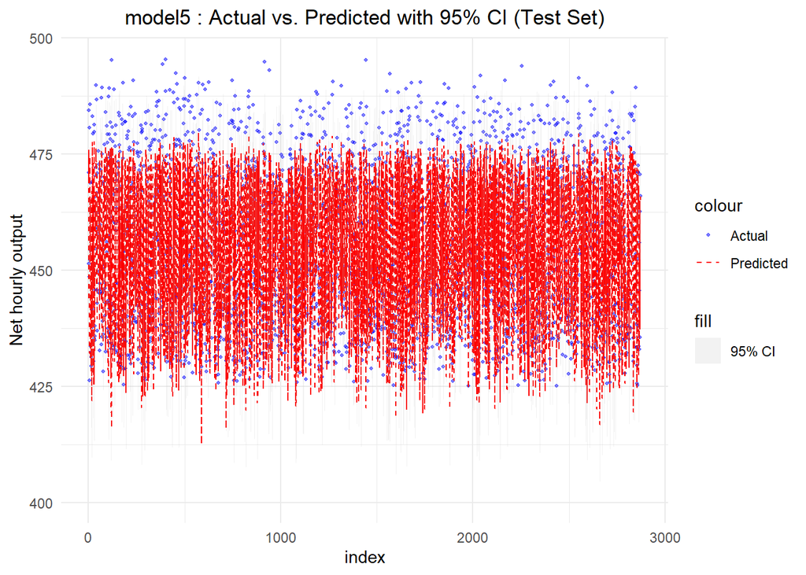

```r
# Plot actual vs. predicted values with 95% CI
p_actual_vs_pred_ci <- ggplot(results_best_model_df, aes(x = index)) +
  geom_point(aes(y = actual, color = "Actual"), alpha = 0.5, size=0.7) + # Actual values
  geom_line(aes(y = predicted, color = "Predicted"), linetype = "dashed") + # Predicted values
  geom_ribbon(aes(ymin = lower_ci, ymax = upper_ci, fill = "95% CI"), alpha = 0.2) + # Confidence interval
  labs(title = paste(best_model_name, ": Actual vs. Predicted with 95% CI (Test Set)"), y = "Net hourly output") +
  scale_color_manual(values = c("Actual" = "blue", "Predicted" = "red")) +
  scale_fill_manual(values = c("95% CI" = "gray")) +
  theme(plot.title = element_text(hjust = 0.5))
print(p_actual_vs_pred_ci)
```

```r
# --- Evaluate Model Performance on Test Set ---
residuals_test_best <- y_test_best - y_pred_test_best # Test set residuals
rmse_best <- sqrt(mean(residuals_test_best^2))        # Root Mean Squared Error
mae_best <- mean(abs(residuals_test_best))           # Mean Absolute Error
# R-squared: 1 - (RSS_test / TSS_test)
r_squared_best <- 1 - (sum(residuals_test_best^2) / sum((y_test_best - mean(y_test_best))^2))

cat(paste("\nEvaluation Metrics for", best_model_name, "on Test Set:\n"))
```

```
##
## Evaluation Metrics for model5 on Test Set:
```

```r
cat(sprintf("RMSE: %.4f\nMAE: %.4f\nR²: %.4f\n", rmse_best, mae_best, r_squared_best))
```

```
## RMSE: 6.1288
## MAE: 4.9256
## R²: 0.8709
```

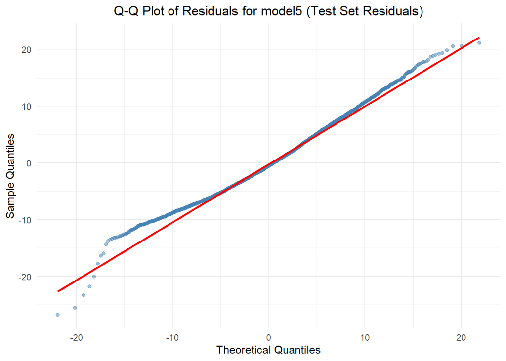

```r
# Plot Q-Q of residuals for the test set
plot_qq_residuals_func(y_test_best, as.vector(y_pred_test_best), paste(best_model_name, "(Test Set Residuals)"))
```

```r
# Shapiro-Wilk test for normality of residuals (for N between 3 and 5000)
# If N > 5000, sample 5000 residuals for the test.
if (length(residuals_test_best) >=3 && length(residuals_test_best) <= 5000 ) {
    print(shapiro.test(residuals_test_best))
} else if (length(residuals_test_best) > 5000) {
    cat("Performing Shapiro-Wilk test on a sample of 5000 residuals due to large dataset.\n")
    print(shapiro.test(sample(residuals_test_best, 5000)))
}
```

```
##
##  Shapiro-Wilk normality test
##
## data:  residuals_test_best
## W = 0.98871, p-value = 2.556e-14
```

```r
# Store OLS coefficients and sigma_squared from the training phase for Task 3 (ABC)
ols_coefs_for_abc <- as.vector(theta_hat_best_model_train)
names(ols_coefs_for_abc) <- rownames(theta_hat_best_model_train) # Assign names to the coefficient vector
ols_sigma_sq_for_abc <- sigma_squared_best_model_est_train # Store estimated error variance
```

Task 3: Approximate Bayesian Computation (ABC) This task performs Approximate Bayesian Computation (ABC) to estimate the posterior distributions of the two most influential parameters of the selected ‘best model’ (model5), while keeping other parameters fixed at their OLS estimates.

```r
# --- Task 3: Approximate Bayesian Computation (ABC) ---

cat("\n========================================\n")
cat("Task 3: Approximate Bayesian Computation (ABC)\n")
```

```
## Task 3: Approximate Bayesian Computation (ABC)
```

```r
cat("========================================\n")
# 3.1 Identify the two parameters with the largest absolute OLS estimates
# from the model trained in Task 2.7 (model5 on training data).
# Other parameters will be fixed at their OLS estimates.

cat("OLS coefficients for the selected model (model5) on scaled training data:\n")
```

```
## OLS coefficients for the selected model (model5) on scaled training data:
```

```r
# ols_coefs_for_abc and ols_sigma_sq_for_abc should be defined at the end of Task 2.7
print(ols_coefs_for_abc)
```

```
## (Intercept)          x4       x1_sq       x3_sq
##  454.402246    1.411504  -10.642313   -5.098567
```

```r
# Exclude the intercept to find the two slope coefficients with the largest absolute values
slope_coefs <- ols_coefs_for_abc[names(ols_coefs_for_abc) != "(Intercept)"]
sorted_abs_slope_coefs <- sort(abs(slope_coefs), decreasing = TRUE) # Sort by absolute value

# Check if there are at least two slope coefficients
if (length(sorted_abs_slope_coefs) < 2) {
  stop("The selected model has fewer than two slope coefficients. ABC task requires selecting two.")
}
# Select the names of the top two parameters
params_for_abc_names <- names(sorted_abs_slope_coefs)[1:2]

cat("\nParameters selected for ABC (largest absolute OLS estimates):\n")
```

```
##
## Parameters selected for ABC (largest absolute OLS estimates):
```

```r
print(params_for_abc_names)
```

```
## [1] "x1_sq" "x3_sq"
```

```r
# Get the OLS estimates for these two parameters
param1_ols_est <- ols_coefs_for_abc[params_for_abc_names[1]]
param2_ols_est <- ols_coefs_for_abc[params_for_abc_names[2]]

cat(paste("\nOLS estimate for", params_for_abc_names[1], ":", param1_ols_est, "\n"))
```

```
##
## OLS estimate for x1_sq : -10.6423129471256
```

```r
cat(paste("OLS estimate for", params_for_abc_names[2], ":", param2_ols_est, "\n"))
```

```
## OLS estimate for x3_sq : -5.09856671428902
```

```r
# Get the OLS estimates for the parameters that will be kept fixed
fixed_params_ols_est <- ols_coefs_for_abc[!names(ols_coefs_for_abc) %in% params_for_abc_names]
cat("\nFixed parameters (using OLS estimates from training data):\n")
```

```
##
## Fixed parameters (using OLS estimates from training data):
```

```r
print(fixed_params_ols_est)
```

```
## (Intercept)          x4
##  454.402246    1.411504
```

```r
# Use the full design matrix from the training set (scaled predictors + intercept)
# X_train_best_bias_for_sigma was defined in Task 2.7
X_train_full_design_df <- X_train_best_bias_for_sigma
X_train_full_design_matrix <- as.matrix(X_train_full_design_df)


# 3.2 Define Uniform priors for the two selected parameters.
# The range of the uniform prior is centered around the OLS estimate.
define_prior_range <- function(ols_est, scale_factor = 1.0) {
  abs_est <- abs(ols_est)
  # If OLS estimate is very small, define a default range to avoid an overly narrow prior
  if (abs_est < 1e-4) { # Check if estimate is close to zero
    range_val <- 0.5 # Default range if OLS estimate is tiny
  } else {
    range_val <- scale_factor * abs_est # Range is proportional to the OLS estimate
  }
  return(c(ols_est - range_val, ols_est + range_val)) # [center - range, center + range]
}

# Define prior ranges for the two parameters selected for ABC
prior_range_param1 <- define_prior_range(param1_ols_est, scale_factor = 1.0) # Scale factor can be adjusted
prior_range_param2 <- define_prior_range(param2_ols_est, scale_factor = 1.0)

cat(paste("\nPrior range for", params_for_abc_names[1], ": [", prior_range_param1[1], ",", prior_range_param1[2], "]\n"))
```

```
##
## Prior range for x1_sq : [ -21.2846258942511 , 0 ]
```

```r
cat(paste("Prior range for", params_for_abc_names[2], ": [", prior_range_param2[1], ",", prior_range_param2[2], "]\n"))
```

```
## Prior range for x3_sq : [ -10.197133428578 , 0 ]
```

```r
# 3.3 Perform rejection ABC.
# - Draw samples from the Uniform priors for the two parameters.
# - Keep other parameters fixed at their OLS estimates.
# - Calculate RSS for the simulated parameters.
# - Accept the sample if simulated RSS is less than a tolerance (epsilon).

n_abc_simulations <- 50000 # Number of simulations to run for ABC
accepted_samples_list <- list() # Use a list to efficiently collect data frames of accepted samples

# Function to calculate RSS (already defined, but can be redefined or called if needed)
calculate_rss <- function(y_true, y_pred) {
  sum((y_true - y_pred)^2)
}

# Calculate the observed RSS from the OLS model on the training data.
# This will be used to set the tolerance (epsilon).
# Ensure coefficients are in the same order as columns in X_train_full_design_matrix
ols_coefs_ordered_for_rss <- ols_coefs_for_abc[colnames(X_train_full_design_matrix)]
y_pred_train_ols <- X_train_full_design_matrix %*% ols_coefs_ordered_for_rss # Predictions using OLS parameters
observed_rss_train <- calculate_rss(y_train_best, y_pred_train_ols) # RSS for OLS model on training data
cat(paste("\nObserved RSS from OLS on training data:", observed_rss_train, "\n"))
```

```
##
## Observed RSS from OLS on training data: 257841.131843422
```

```r
# Set the tolerance (epsilon) for ABC: e.g., 105% of the observed RSS
epsilon <- observed_rss_train * 1.05
cat(paste("ABC Tolerance epsilon (max RSS for acceptance):", epsilon, "\n"))
```

```
## ABC Tolerance epsilon (max RSS for acceptance): 270733.188435593
```

```r
# Get all parameter names (including intercept and fixed ones) in the correct order
all_param_names <- names(ols_coefs_for_abc)

# Initialize progress bar
pb <- txtProgressBar(min = 0, max = n_abc_simulations, style = 3)
```

```
##   |                                                                              |                                                                      |   0%
```

```r
# ABC simulation loop
for (i in 1:n_abc_simulations) {
  # Sample the two parameters from their uniform priors
  sampled_param1 <- runif(1, min = prior_range_param1[1], max = prior_range_param1[2])
  sampled_param2 <- runif(1, min = prior_range_param2[1], max = prior_range_param2[2])

  # Create a full parameter vector for the current simulation
  current_theta_abc <- numeric(length(all_param_names))
  names(current_theta_abc) <- all_param_names

  # Assign sampled values to the two ABC parameters
  current_theta_abc[params_for_abc_names[1]] <- sampled_param1
  current_theta_abc[params_for_abc_names[2]] <- sampled_param2

  # Assign fixed OLS estimates to the other parameters
  for (p_name in names(fixed_params_ols_est)) {
    current_theta_abc[p_name] <- fixed_params_ols_est[p_name]
  }

  # Ensure the parameter vector is in the same order as columns of the design matrix
  current_theta_abc_ordered <- current_theta_abc[colnames(X_train_full_design_matrix)]

  # Predict y values using the simulated parameters and training data
  y_pred_abc <- X_train_full_design_matrix %*% current_theta_abc_ordered
  # Calculate RSS for the simulated parameters
  rss_simulated <- calculate_rss(y_train_best, y_pred_abc)

  # Rejection step: accept if simulated RSS is less than epsilon
  if (rss_simulated < epsilon) {
    # Store the accepted sample (the two parameters and their RSS)
    temp_data_list <- list()
    temp_data_list[[params_for_abc_names[1]]] <- sampled_param1
    temp_data_list[[params_for_abc_names[2]]] <- sampled_param2
    temp_data_list[["rss"]] <- rss_simulated
    accepted_samples_list[[length(accepted_samples_list) + 1]] <- as.data.frame(temp_data_list)
  }
  setTxtProgressBar(pb, i) # Update progress bar
}
```

[output not shown]

```r
close(pb) # Close progress bar
```

```r
# Combine all accepted samples from the list into a single data frame
accepted_samples <- do.call(rbind, accepted_samples_list)

# Check if any samples were accepted
if (is.null(accepted_samples) || nrow(accepted_samples) == 0) {
    cat("\nNo samples were accepted. Try increasing n_abc_simulations, widening priors, or increasing epsilon.\n")
    # Create an empty data frame with correct column names if no samples accepted,
    # to avoid errors in subsequent plotting code if it expects this data frame.
    accepted_samples <- data.frame(matrix(ncol = 3, nrow = 0))
    colnames(accepted_samples) <- c(params_for_abc_names, "rss")
} else {
    cat(paste("\nNumber of accepted samples:", nrow(accepted_samples), "out of", n_abc_simulations, "\n"))
    cat(paste("Acceptance rate:", nrow(accepted_samples) / n_abc_simulations * 100, "%\n"))
}
```

```
##
## Number of accepted samples: 2523 out of 50000
## Acceptance rate: 5.046 %
```

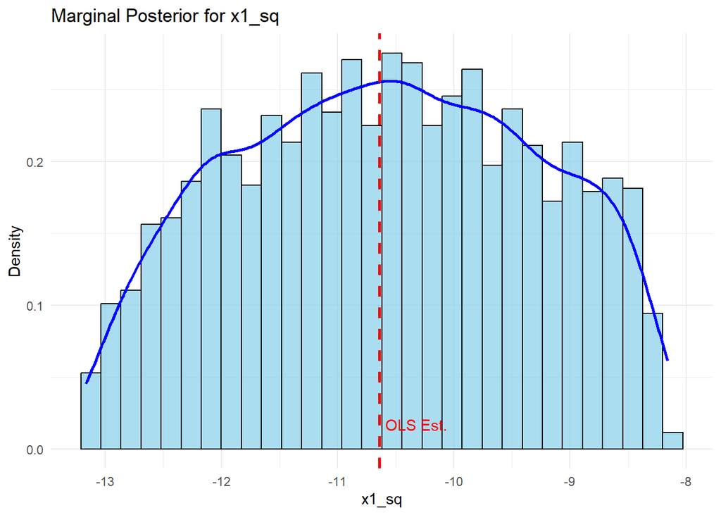

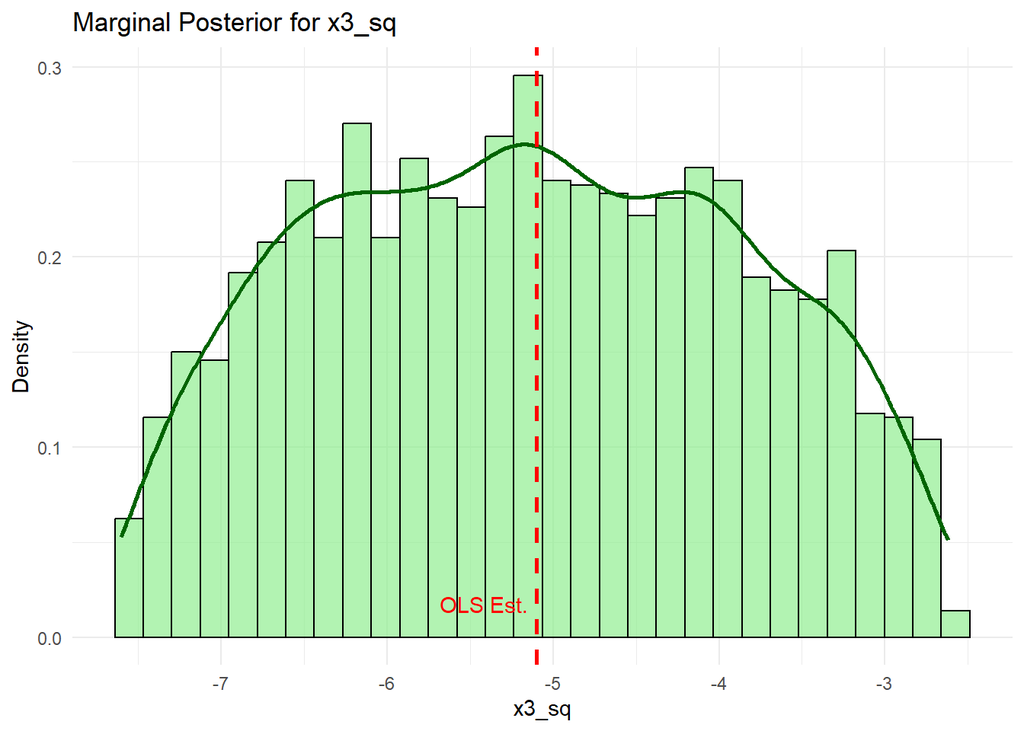

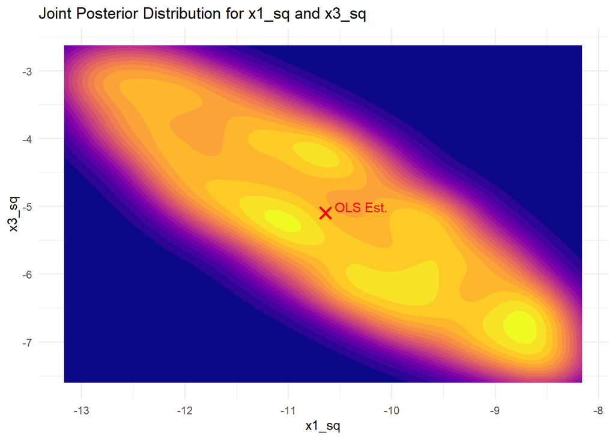

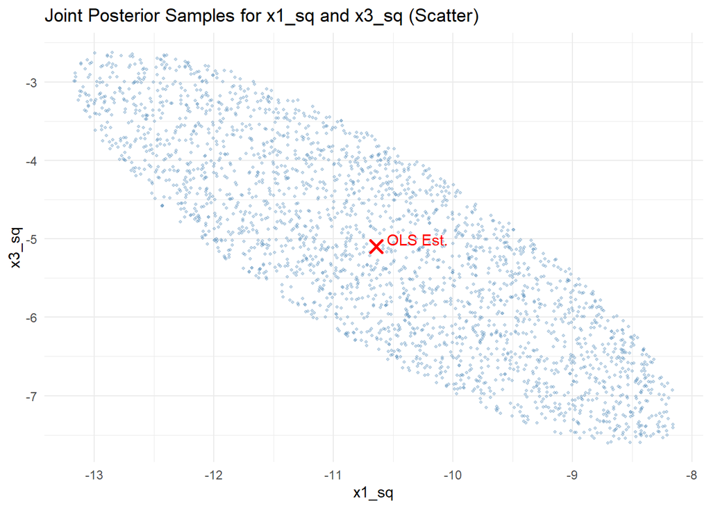

```r
# 3.4 Plot the joint and marginal posterior distributions of the two parameters.
if (is.null(accepted_samples) || nrow(accepted_samples) < 2) { # Need at least 2 samples for density plots
  warning("Too few samples accepted for plotting. Ensure n_abc_simulations is high enough, priors are appropriate, and epsilon is not too strict.")
} else {
  param1_label <- params_for_abc_names[1] # Name of the first ABC parameter
  param2_label <- params_for_abc_names[2] # Name of the second ABC parameter

  # Ensure columns are numeric before plotting (important if accepted_samples was created as empty matrix then named)
  accepted_samples[[param1_label]] <- as.numeric(accepted_samples[[param1_label]])
  accepted_samples[[param2_label]] <- as.numeric(accepted_samples[[param2_label]])

  # --- Marginal Posterior for Parameter 1 ---
  # Use .data[[param_label]] for robust mapping in aes()
  p_marginal1 <- ggplot(accepted_samples, aes(x = .data[[param1_label]])) +
    geom_histogram(aes(y = after_stat(density)), bins = 30, fill = "skyblue", color = "black", alpha = 0.7) + # Histogram
    geom_density(color = "blue", linewidth = 1) + # Density curve
    geom_vline(xintercept = param1_ols_est, color = "red", linetype = "dashed", linewidth = 1) + # OLS estimate line
    labs(title = paste("Marginal Posterior for", param1_label),
         x = param1_label, y = "Density") +
    # Annotate OLS estimate
    annotate("text", x = param1_ols_est, y = max(density(accepted_samples[[param1_label]])$y)*0.05,
             label = "OLS Est.", vjust = 0,
             hjust = ifelse(param1_ols_est > median(accepted_samples[[param1_label]]), 1.1, -0.1), color = "red") +
    theme_minimal()
  print(p_marginal1)

  # --- Marginal Posterior for Parameter 2 ---
  p_marginal2 <- ggplot(accepted_samples, aes(x = .data[[param2_label]])) +
    geom_histogram(aes(y = after_stat(density)), bins = 30, fill = "lightgreen", color = "black", alpha = 0.7) +
    geom_density(color = "darkgreen", linewidth = 1) +
    geom_vline(xintercept = param2_ols_est, color = "red", linetype = "dashed", linewidth = 1) +
    labs(title = paste("Marginal Posterior for", param2_label),
         x = param2_label, y = "Density") +
    annotate("text", x = param2_ols_est, y = max(density(accepted_samples[[param2_label]])$y)*0.05,
             label = "OLS Est.", vjust = 0,
             hjust=ifelse(param2_ols_est > median(accepted_samples[[param2_label]]), 1.1, -0.1), color = "red") +
    theme_minimal()
  print(p_marginal2)

  # --- Joint Posterior Distribution (Density Plot) ---
  p_joint <- ggplot(accepted_samples, aes(x = .data[[param1_label]], y = .data[[param2_label]])) +
    stat_density_2d_filled(aes(fill = after_stat(level)), geom = "polygon", contour_var = "density", bins=20) + # 2D density contours
    # geom_point(alpha = 0.1, size=0.5, color="white") + # Optional: overlay points if few samples
    scale_fill_viridis_d(option = "plasma") + # Color scale for density
    # Add point for OLS estimates
    geom_point(data=data.frame(x=param1_ols_est, y=param2_ols_est), aes(x=x, y=y),
               color = "red", size = 3, shape = 4, stroke=1.5) + # OLS estimate as a cross
    annotate("text", x = param1_ols_est, y = param2_ols_est, label = " OLS Est.",
             color = "red", hjust = -0.1, vjust = -0.1) + # Label for OLS estimate
    labs(title = paste("Joint Posterior Distribution for", param1_label, "and", param2_label),
         x = param1_label, y = param2_label) +
    theme_minimal() +
    guides(fill="none") # Remove legend for fill
  print(p_joint)

  # --- Joint Posterior Distribution (Scatter Plot of Accepted Samples) ---
  p_joint_scatter <- ggplot(accepted_samples, aes(x = .data[[param1_label]], y = .data[[param2_label]])) +
    geom_point(alpha = 0.3, color="steelblue", size=0.8) + # Scatter plot of accepted samples
    geom_point(data=data.frame(x=param1_ols_est, y=param2_ols_est), aes(x=x, y=y),
               color = "red", size = 3, shape = 4, stroke=1.5) + # OLS estimate as a cross
    annotate("text", x = param1_ols_est, y = param2_ols_est, label = " OLS Est.",
             color = "red", hjust = -0.1, vjust = -0.1) + # Label for OLS estimate
    labs(title = paste("Joint Posterior Samples for", param1_label, "and", param2_label, "(Scatter)"),
         x = param1_label, y = param2_label) +
    theme_minimal()
  print(p_joint_scatter)
}
```

```r
cat("\n--- End of Task 3 ---\n")
```

```
##
## --- End of Task 3 ---
```